# Week 8 Project - Identify Alternative Investment Basket or Funds Ideas from S&P500 Companies for IB Company

Raju Penmetcha

2017-05-13

# R Packages

The packages you will need to install for the week are **readr**, **dplyr**, **ggplot2**, **VIM**, **lessR**, **fpc**, and **cluster**.

# Analysis Goal

IB Company: Identify alternative stock investment ideas from S&P500 index component companies to establish new investment baskets or index funds for better customer asset allocation and total return potential.

Standard and Poor’s 500 (S&P 500) is American stock market index based on market capitalizations of 500 (plus 5 due to share class) large companies.

A drawback using S&P 500 index is it is disproportionately weighted towards large companies. The top 50 companies account for around 50% of the index value.

Identify more focused equal weighted high profitable and return potential companies out of S&P 500 index.

[figure not shown]

S&P 500

# The Dataset

- constituents.csv: general description of each company with division on sectors.
- fundamentals.csv: List of companies in the S&P 500 (Standard and Poor’s 500). The S&P 500 is a free-float, capitalization-weighted index of the top 500 publicly listed stocks in the US (top 500 by market cap). The dataset includes a list of all the stocks contained therein and associated key financials such as gross margin, operating margin, ROE, earnings, cash ratio, fixed assets, total revenue etc.
- Data sets are extracted from https://www.kaggle.com/dgawlik/nyse and http://data.okfn.org/data/core/s-and-p-500-companies websites.

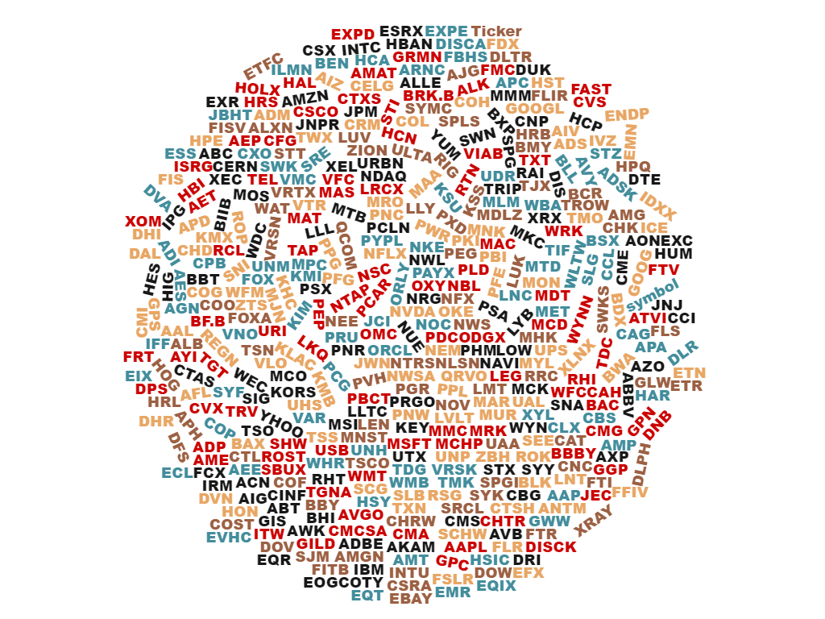

S&P 500 constituents stocks

# Getting Started

```r
library(readr)
library(dplyr)
setwd("C:/Users/Jupiter/Downloads/RU/BIA6301ADM/Homework")

# finanaical ratios
rm(sp500_fin)
sp500_fin <- read_csv("C:/Users/Jupiter/Downloads/RU/BIA6301ADM/Homework/submission/week8/ADM_Week8_Project/ADM_Week8_Project/data/fundamentals_edit.csv")
# Company description and industry category
rm(sp500_dsc)
sp500_dsc <- read_csv("C:/Users/Jupiter/Downloads/RU/BIA6301ADM/Homework/submission/week8/ADM_Week8_Project/ADM_Week8_Project/data/constituents-financials_edit.csv")
str(sp500_fin)
```

```
## Classes 'tbl_df', 'tbl' and 'data.frame':    443 obs. of  25 variables:
##  $ Ticker Symbol                   : chr  "AAL" "AAP" "AAPL" "ABBV" ...
##  $ For Year                        : int  2015 2015 2015 2015 2015 2015 2015 2015 2015 2015 ...
##  $ After Tax ROE                   : int  135 19 45 130 22 21 9 14 10 30 ...
##  $ Gross Margin                    : int  73 45 40 80 3 57 84 66 6 30 ...
##  $ Operating Margin                : int  15 8 30 33 0 14 19 24 3 20 ...
##  $ Pre-Tax Margin                  : int  11 8 31 29 0 16 18 24 3 14 ...
##  $ Pre-Tax ROE                     : int  82 31 61 168 44 15 12 16 13 46 ...
##  $ Profit Margin                   : int  19 5 23 23 0 22 13 20 3 9 ...
##  $ Cash and Cash Equivalents       : num  1.08e+09 9.08e+07 2.11e+10 8.40e+09 2.17e+09 ...
##  $ Cost of Revenue                 : num  1.11e+10 5.31e+09 1.40e+11 4.50e+09 1.32e+11 ...
##  $ Earnings Before Interest and Tax: num  5.50e+09 8.18e+08 7.25e+10 7.33e+09 3.78e+08 ...
##  $ Fixed Assets                    : num  2.75e+10 1.43e+09 2.25e+10 2.56e+09 1.19e+09 ...
##  $ Gross Profit                    : num  2.99e+10 4.42e+09 9.36e+10 1.84e+10 3.53e+09 ...
##  $ Liabilities                     : num  -6.33e+08 1.75e+08 1.52e+10 1.50e+09 5.12e+09 ...
##  $ Long-Term Debt                  : num  1.83e+10 1.21e+09 5.33e+10 2.92e+10 3.74e+09 ...
##  $ Net Cash Flow                   : num  -6.04e+08 -1.39e+07 7.28e+09 5.10e+07 3.59e+08 ...
##  $ Net Cash Flow-Operating         : num  6.25e+09 6.90e+08 8.13e+10 7.54e+09 3.92e+09 ...
##  $ Net Income Adjustments          : num  -2.66e+09 3.02e+07 4.97e+09 1.05e+09 1.58e+09 ...
##  $ Net Income-Cont. Operations     : num  7.61e+09 4.73e+08 5.34e+10 5.14e+09 -1.38e+08 ...
##  $ Retained Earnings               : num  -1.23e+09 2.02e+09 9.23e+10 2.25e+09 1.16e+09 ...
##  $ Sale and Purchase of Stock      : num  -3.85e+09 -1.49e+06 -3.47e+10 -7.42e+09 -1.67e+09 ...
##  $ Total Assets                    : num  4.84e+10 8.13e+09 2.90e+11 5.30e+10 2.80e+10 ...
##  $ Total Equity                    : num  5.64e+09 2.46e+09 1.19e+11 3.94e+09 6.16e+08 ...
##  $ Total Liabilities               : num  4.28e+10 5.67e+09 1.71e+11 4.91e+10 2.73e+10 ...
##  $ Total Revenue                   : num  4.10e+10 9.74e+09 2.34e+11 2.29e+10 1.36e+11 ...
##  - attr(*, "spec")=List of 2
##   ..$ cols   :List of 25
##   .. ..$ Ticker Symbol                   : list()
##   .. .. ..- attr(*, "class")= chr  "collector_character" "collector"
##   .. ..$ For Year                        : list()
##   .. .. ..- attr(*, "class")= chr  "collector_integer" "collector"
##   .. ..$ After Tax ROE                   : list()
##   .. .. ..- attr(*, "class")= chr  "collector_integer" "collector"
##   .. ..$ Gross Margin                    : list()
##   .. .. ..- attr(*, "class")= chr  "collector_integer" "collector"
##   .. ..$ Operating Margin                : list()
##   .. .. ..- attr(*, "class")= chr  "collector_integer" "collector"
##   .. ..$ Pre-Tax Margin                  : list()
##   .. .. ..- attr(*, "class")= chr  "collector_integer" "collector"
```

[output cut: 26 more lines]

```
##   .. ..$ Retained Earnings               : list()
##   .. .. ..- attr(*, "class")= chr  "collector_double" "collector"
##   .. ..$ Sale and Purchase of Stock      : list()
##   .. .. ..- attr(*, "class")= chr  "collector_double" "collector"
##   .. ..$ Total Assets                    : list()
##   .. .. ..- attr(*, "class")= chr  "collector_double" "collector"
##   .. ..$ Total Equity                    : list()
##   .. .. ..- attr(*, "class")= chr  "collector_double" "collector"
##   .. ..$ Total Liabilities               : list()
##   .. .. ..- attr(*, "class")= chr  "collector_double" "collector"
##   .. ..$ Total Revenue                   : list()
##   .. .. ..- attr(*, "class")= chr  "collector_double" "collector"
##   ..$ default: list()
##   .. ..- attr(*, "class")= chr  "collector_guess" "collector"
##   ..- attr(*, "class")= chr "col_spec"
```

```r
str(sp500_dsc)
```

```
## Classes 'tbl_df', 'tbl' and 'data.frame':    503 obs. of  8 variables:
##  $ Symbol        : chr  "MMM" "ABT" "ABBV" "ACN" ...
##  $ Name          : chr  "3M Company" "Abbott Laboratories" "AbbVie" "Accenture plc" ...
##  $ Sector        : chr  "Industrials" "Health Care" "Health Care" "Information Technology" ...
##  $ Dividend Yield: num  2.48 2.34 4.04 1.96 0.64 0.25 0 0.15 4.16 1.53 ...
##  $ Earnings/Share: num  8.16 0.94 3.63 6.76 1.28 6.92 2.32 6.2 -1.71 6.41 ...
##  $ Book Value    : num  17.26 13.94 2.91 11.95 12.23 ...
##  $ Market Cap    : num  112.7 77.8 101.5 77.3 36.1 ...
##  $ EBITDA        : num  8.7 4.59 10.95 5.66 2.14 ...
##  - attr(*, "spec")=List of 2
##   ..$ cols   :List of 8
##   .. ..$ Symbol        : list()
##   .. .. ..- attr(*, "class")= chr  "collector_character" "collector"
##   .. ..$ Name          : list()
##   .. .. ..- attr(*, "class")= chr  "collector_character" "collector"
##   .. ..$ Sector        : list()
##   .. .. ..- attr(*, "class")= chr  "collector_character" "collector"
##   .. ..$ Dividend Yield: list()
##   .. .. ..- attr(*, "class")= chr  "collector_double" "collector"
##   .. ..$ Earnings/Share: list()
##   .. .. ..- attr(*, "class")= chr  "collector_double" "collector"
##   .. ..$ Book Value    : list()
##   .. .. ..- attr(*, "class")= chr  "collector_double" "collector"
##   .. ..$ Market Cap    : list()
##   .. .. ..- attr(*, "class")= chr  "collector_double" "collector"
##   .. ..$ EBITDA        : list()
##   .. .. ..- attr(*, "class")= chr  "collector_double" "collector"
##   ..$ default: list()
##   .. ..- attr(*, "class")= chr  "collector_guess" "collector"
##   ..- attr(*, "class")= chr "col_spec"
```

```r
names(sp500_fin) <- make.names(names(sp500_fin))
names(sp500_dsc) <- make.names(names(sp500_dsc))


# Add company name and industory to financial data set
sp500.match.data <- inner_join(sp500_fin, sp500_dsc, by = c("Ticker.Symbol" = "Symbol"))
```

# Exploratory Data Analysis

```r
# Refine and rearrnge columns in the dataset
rm(sp500)
sp500 <- sp500.match.data[,c(1,26:32,3:25)]

#aggregate(sp500, list(sp500$Ticker.Symbol), mean)
summary(sp500)
```

```
##  Ticker.Symbol          Name              Sector          Dividend.Yield
##  Length:442         Length:442         Length:442         Min.   : 0.000
##  Class :character   Class :character   Class :character   1st Qu.: 0.770
##  Mode  :character   Mode  :character   Mode  :character   Median : 1.795
##                                                           Mean   : 1.894
##                                                           3rd Qu.: 2.785
##                                                           Max.   :14.630
##  Earnings.Share      Book.Value       Market.Cap         EBITDA
##  Min.   :-33.880   Min.   :-64.18   Min.   :  2.95   Min.   :-0.7360
##  1st Qu.:  1.515   1st Qu.: 10.35   1st Qu.: 11.44   1st Qu.: 0.8985
##  Median :  2.785   Median : 18.84   Median : 19.50   Median : 1.6200
##  Mean   :  3.360   Mean   : 24.32   Mean   : 39.90   Mean   : 3.3858
##  3rd Qu.:  4.910   3rd Qu.: 33.88   3rd Qu.: 36.32   3rd Qu.: 3.4550
##  Max.   : 49.900   Max.   :199.64   Max.   :732.00   Max.   :69.7500
##  After.Tax.ROE     Gross.Margin    Operating.Margin Pre.Tax.Margin
##  Min.   :  1.00   Min.   :  0.00   Min.   :  0.00   Min.   :  0.00
##  1st Qu.: 10.00   1st Qu.: 30.00   1st Qu.:  9.00   1st Qu.:  9.00
##  Median : 17.00   Median : 44.00   Median : 15.00   Median : 14.00
##  Mean   : 37.84   Mean   : 46.96   Mean   : 21.23   Mean   : 20.75
##  3rd Qu.: 28.00   3rd Qu.: 63.75   3rd Qu.: 23.00   3rd Qu.: 22.75
##  Max.   :917.00   Max.   :100.00   Max.   :437.00   Max.   :442.00
##   Pre.Tax.ROE      Profit.Margin    Cash.and.Cash.Equivalents
##  Min.   :   1.00   Min.   :  0.00   Min.   :4.710e+05
##  1st Qu.:  12.25   1st Qu.:  6.00   1st Qu.:2.891e+08
##  Median :  22.50   Median : 11.00   Median :8.418e+08
##  Mean   :  52.81   Mean   : 16.08   Mean   :8.822e+09
##  3rd Qu.:  38.00   3rd Qu.: 17.00   3rd Qu.:2.269e+09
##  Max.   :1100.00   Max.   :369.00   Max.   :7.140e+11
##  Cost.of.Revenue     Earnings.Before.Interest.and.Tax  Fixed.Assets
##  Min.   :0.000e+00   Min.   :-2.793e+10               Min.   :0.000e+00
##  1st Qu.:1.255e+09   1st Qu.: 5.864e+08               1st Qu.:6.451e+08
##  Median :3.884e+09   Median : 1.140e+09               Median :2.304e+09
##  Mean   :1.204e+10   Mean   : 2.471e+09               Mean   :8.736e+09
##  3rd Qu.:9.904e+09   3rd Qu.: 2.537e+09               3rd Qu.:9.570e+09
##  Max.   :3.650e+11   Max.   : 7.252e+10               Max.   :2.520e+11
##   Gross.Profit         Liabilities         Long.Term.Debt
##  Min.   :-1.265e+10   Min.   :-4.017e+10   Min.   :0.000e+00
##  1st Qu.: 1.657e+09   1st Qu.:-9.260e+07   1st Qu.:1.385e+09
##  Median : 3.219e+09   Median : 6.084e+06   Median :3.800e+09
##  Mean   : 7.288e+09   Mean   :-2.834e+07   Mean   :9.195e+09
```

[output cut: 15 more lines]

```
##  Max.   : 5.339e+10          Max.   : 4.120e+11
##  Sale.and.Purchase.of.Stock  Total.Assets        Total.Equity
##  Min.   :-3.471e+10         Min.   :1.475e+09   Min.   :-1.324e+10
##  1st Qu.:-9.792e+08         1st Qu.:7.220e+09   1st Qu.: 2.356e+09
##  Median :-2.958e+08         Median :1.586e+10   Median : 5.159e+09
##  Mean   :-8.105e+08         Mean   :5.743e+10   Mean   : 1.209e+10
##  3rd Qu.: 0.000e+00         3rd Qu.:3.901e+10   3rd Qu.: 1.071e+10
##  Max.   : 5.410e+09         Max.   :2.350e+12   Max.   : 2.560e+11
##  Total.Liabilities   Total.Revenue
##  Min.   :3.062e+08   Min.   :7.440e+08
##  1st Qu.:4.438e+09   1st Qu.:3.958e+09
##  Median :1.018e+10   Median :8.528e+09
##  Mean   :4.534e+10   Mean   :2.008e+10
##  3rd Qu.:2.524e+10   3rd Qu.:1.736e+10
##  Max.   :2.100e+12   Max.   :4.860e+11
```

## Identify Missing Data Values

```r
library (ggplot2)

pMiss <- function(x){sum(is.na(x))/length(x)*100}
apply(sp500,2,pMiss)
```

```
##                    Ticker.Symbol                             Name
##                                0                                0
##                           Sector                   Dividend.Yield
##                                0                                0
##                   Earnings.Share                       Book.Value
##                                0                                0
##                       Market.Cap                           EBITDA
##                                0                                0
##                    After.Tax.ROE                     Gross.Margin
##                                0                                0
##                 Operating.Margin                   Pre.Tax.Margin
##                                0                                0
##                      Pre.Tax.ROE                    Profit.Margin
##                                0                                0
##        Cash.and.Cash.Equivalents                  Cost.of.Revenue
##                                0                                0
## Earnings.Before.Interest.and.Tax                     Fixed.Assets
##                                0                                0
##                     Gross.Profit                      Liabilities
##                                0                                0
##                   Long.Term.Debt                    Net.Cash.Flow
##                                0                                0
##          Net.Cash.Flow.Operating           Net.Income.Adjustments
##                                0                                0
##      Net.Income.Cont..Operations                Retained.Earnings
##                                0                                0
##       Sale.and.Purchase.of.Stock                     Total.Assets
##                                0                                0
##                     Total.Equity                Total.Liabilities
##                                0                                0
##                    Total.Revenue
##                                0
```

## Visualize data to identify any missing data

```r
library(VIM)
```

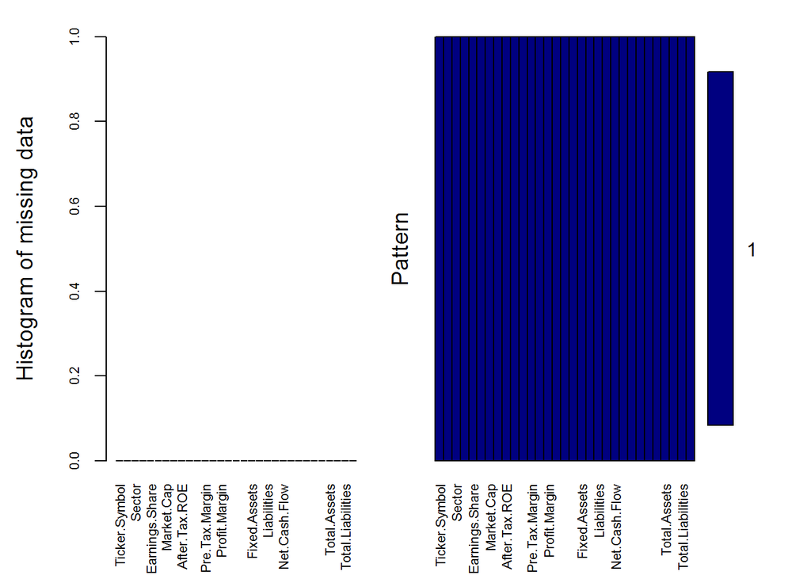

```
##
##  Variables sorted by number of missings:
##                          Variable Count
##                     Ticker.Symbol     0
##                              Name     0
##                            Sector     0
##                    Dividend.Yield     0
##                    Earnings.Share     0
##                        Book.Value     0
##                        Market.Cap     0
##                            EBITDA     0
##                     After.Tax.ROE     0
##                      Gross.Margin     0
##                  Operating.Margin     0
##                    Pre.Tax.Margin     0
##                       Pre.Tax.ROE     0
##                     Profit.Margin     0
##         Cash.and.Cash.Equivalents     0
##                   Cost.of.Revenue     0
##  Earnings.Before.Interest.and.Tax     0
##                      Fixed.Assets     0
##                      Gross.Profit     0
##                       Liabilities     0
##                    Long.Term.Debt     0
##                     Net.Cash.Flow     0
##           Net.Cash.Flow.Operating     0
##            Net.Income.Adjustments     0
##       Net.Income.Cont..Operations     0
##                 Retained.Earnings     0
##        Sale.and.Purchase.of.Stock     0
##                      Total.Assets     0
##                      Total.Equity     0
##                 Total.Liabilities     0
##                     Total.Revenue     0
```

```r
aggr_plot <- aggr(sp500, col=c('navyblue','red'), numbers=TRUE, sortVars=TRUE, labels=names(sp500), cex.axis=.7, gap=3, ylab=c("Histogram of missing data","Pattern"))
```

*No missing data is found in the dataset*

## Visualize numeric data distribution

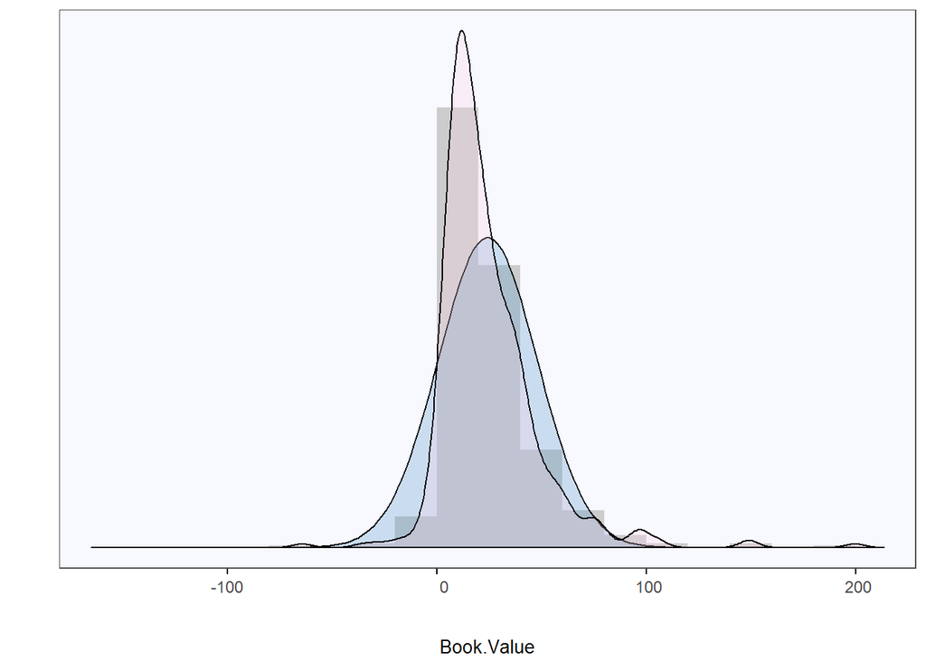

```
##
##
## Sample Size:  442
## Missing Values:  0
##
## Density bandwidth for general curve: 4.6753
## For a smoother curve, increase bandwidth with option: bw
##
## Null hypothesis is a normal population
## Shapiro-Wilk normality test:  W = 0.8301,  p-value = 0.0000
##
##
## (Box plot) Outliers: 23
## Small:  -64.18 -35.1 -27.23
## Large: 70.63 71.57 73.26 74.07 74.26 76.66 76.95 77.88 78.47 83.05 94.22 94.5 95.17 97.66 98.96 103.6 106.76 148.91 149.27 199.64
```

```r
library(lessR)
#Density(Gross.Margin, data=sp500)
#Density(Dividend.Yield, data=sp500)
Density(Book.Value, data=sp500)
```

```r
#Density(Net.Cash.Flow, data=sp500)
```

The numeric data columns have outliers and distribution is sparse. We Will use normalization on certain numeric columns to minimize k-means sensitivity to outliers for the analysis.

# Normalize numeric columns in the data set

```r
sp500_ratio <-sp500[,c(4:14)]
sp500_num <-sp500[,c(15:31)]

normalize<- function(x){return((x-min(x))/(max(x)-min(x)))}
sp500_n<-as.data.frame(lapply(sp500_num, normalize))
```

## Summary the new variables

```r
summary(sp500_ratio)
```

```
##  Dividend.Yield   Earnings.Share      Book.Value       Market.Cap
##  Min.   : 0.000   Min.   :-33.880   Min.   :-64.18   Min.   :  2.95
##  1st Qu.: 0.770   1st Qu.:  1.515   1st Qu.: 10.35   1st Qu.: 11.44
##  Median : 1.795   Median :  2.785   Median : 18.84   Median : 19.50
##  Mean   : 1.894   Mean   :  3.360   Mean   : 24.32   Mean   : 39.90
##  3rd Qu.: 2.785   3rd Qu.:  4.910   3rd Qu.: 33.88   3rd Qu.: 36.32
##  Max.   :14.630   Max.   : 49.900   Max.   :199.64   Max.   :732.00
##      EBITDA        After.Tax.ROE     Gross.Margin    Operating.Margin
##  Min.   :-0.7360   Min.   :  1.00   Min.   :  0.00   Min.   :  0.00
##  1st Qu.: 0.8985   1st Qu.: 10.00   1st Qu.: 30.00   1st Qu.:  9.00
##  Median : 1.6200   Median : 17.00   Median : 44.00   Median : 15.00
##  Mean   : 3.3858   Mean   : 37.84   Mean   : 46.96   Mean   : 21.23
##  3rd Qu.: 3.4550   3rd Qu.: 28.00   3rd Qu.: 63.75   3rd Qu.: 23.00
##  Max.   :69.7500   Max.   :917.00   Max.   :100.00   Max.   :437.00
##  Pre.Tax.Margin    Pre.Tax.ROE      Profit.Margin
##  Min.   :  0.00   Min.   :   1.00   Min.   :  0.00
##  1st Qu.:  9.00   1st Qu.:  12.25   1st Qu.:  6.00
##  Median : 14.00   Median :  22.50   Median : 11.00
##  Mean   : 20.75   Mean   :  52.81   Mean   : 16.08
##  3rd Qu.: 22.75   3rd Qu.:  38.00   3rd Qu.: 17.00
##  Max.   :442.00   Max.   :1100.00   Max.   :369.00
```

```r
summary(sp500_n)
```

```
##  Cash.and.Cash.Equivalents Cost.of.Revenue
##  Min.   :0.0000000         Min.   :0.000000
##  1st Qu.:0.0004043         1st Qu.:0.003438
##  Median :0.0011783         Median :0.010641
##  Mean   :0.0123554         Mean   :0.032984
##  3rd Qu.:0.0031776         3rd Qu.:0.027133
##  Max.   :1.0000000         Max.   :1.000000
##  Earnings.Before.Interest.and.Tax  Fixed.Assets       Gross.Profit
##  Min.   :0.0000                   Min.   :0.000000   Min.   :0.0000
##  1st Qu.:0.2839                   1st Qu.:0.002560   1st Qu.:0.1070
##  Median :0.2894                   Median :0.009143   Median :0.1187
##  Mean   :0.3026                   Mean   :0.034665   Mean   :0.1492
##  3rd Qu.:0.3033                   3rd Qu.:0.037977   3rd Qu.:0.1458
##  Max.   :1.0000                   Max.   :1.000000   Max.   :1.0000
##   Liabilities     Long.Term.Debt     Net.Cash.Flow
##  Min.   :0.0000   Min.   :0.000000   Min.   :0.0000
##  1st Qu.:0.7240   1st Qu.:0.003329   1st Qu.:0.3446
##  Median :0.7257   Median :0.009133   Median :0.3506
##  Mean   :0.7251   Mean   :0.022103   Mean   :0.3528
##  3rd Qu.:0.7288   3rd Qu.:0.020761   3rd Qu.:0.3562
##  Max.   :1.0000   Max.   :1.000000   Max.   :1.0000
##  Net.Cash.Flow.Operating Net.Income.Adjustments
##  Min.   :0.00000         Min.   :0.0000
##  1st Qu.:0.03709         1st Qu.:0.7340
##  Median :0.04400         Median :0.7358
##  Mean   :0.06747         Mean   :0.7393
##  3rd Qu.:0.06411         3rd Qu.:0.7402
##  Max.   :1.00000         Max.   :1.0000
##  Net.Income.Cont..Operations Retained.Earnings Sale.and.Purchase.of.Stock
##  Min.   :0.0000              Min.   :0.00000   Min.   :0.0000
##  1st Qu.:0.3036              1st Qu.:0.04595   1st Qu.:0.8407
##  Median :0.3079              Median :0.05159   Median :0.8578
##  Mean   :0.3200              Mean   :0.06617   Mean   :0.8450
##  3rd Qu.:0.3211              3rd Qu.:0.06567   3rd Qu.:0.8652
##  Max.   :1.0000              Max.   :1.00000   Max.   :1.0000
##   Total.Assets       Total.Equity     Total.Liabilities
##  Min.   :0.000000   Min.   :0.00000   Min.   :0.000000
##  1st Qu.:0.002446   1st Qu.:0.05794   1st Qu.:0.001968
##  Median :0.006127   Median :0.06835   Median :0.004701
##  Mean   :0.023826   Mean   :0.09408   Mean   :0.021448
##  3rd Qu.:0.015982   3rd Qu.:0.08896   3rd Qu.:0.011876
##  Max.   :1.000000   Max.   :1.00000   Max.   :1.000000
##  Total.Revenue
##  Min.   :0.000000
##  1st Qu.:0.006623
##  Median :0.016042
##  Mean   :0.039857
##  3rd Qu.:0.034233
##  Max.   :1.000000
```

## Combine all interested data columns into one data frame for analysis

Selected variables are: Company ticker symbol, Name, Sector, Dividend Yield, ROe, Earnings, Market Cap, EBITDA, Book Value, Gross Margin, operating margin, Cash and Cash equivelantes, Net cash flow, total revenu, liabilites, and etc.

```r
sp500_nall <- cbind(sp500[,c(1:3)],sp500_ratio[,c(1:5,7,8,10)],sp500_n[,c(1,9,13:17)])
```

## Create interest data frame with selected variables

```r
interests <- sp500_nall[,4:18] #select interested variables of company valuation and profit margin ratios
```

# Examine and run cluster analsyis?

This analysis will cluster S&P500 companies financial ratios like profitability margins, stock valuation ratios and other variables to identify smaller set of company groupings which provide significant alternative investment opportunities.

## Using Partitioning Approach for the analysis

General process:

1. Choose the number of clusters (k)
2. Partition the dataset into k clusters so that the sum of squared distances is minimized between the data points (p) and some center point [c(i)] in each cluster.

## K-Means Clustering

Build a cluster model with three to nine clusters and then cross validate for final selection.

*Outputs from kmeans:* Size: Number of company stocks in each cluster. Show the coordinates of the cluster centroids for the interested variables.

### What about k=3?

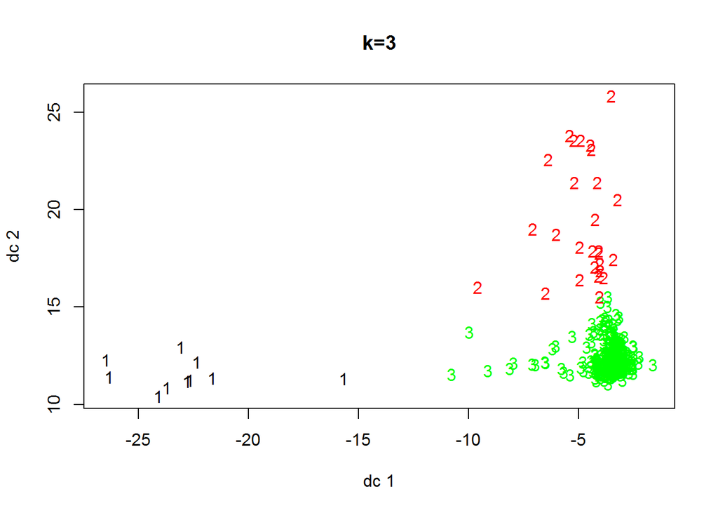

```r
library(fpc) #load this

set.seed(123)
sp500_clusters_3 <- kmeans(interests, centers=3)
plotcluster(interests, sp500_clusters_3$cluster, main="k=3")
```

```r
sp500_clusters_3$size
```

```
## [1]  10  27 405
```

```r
t(sp500_clusters_3$centers) #transpose for ease of reading purpose
```

```
##                                        1           2            3
## Dividend.Yield               1.718000000   2.5440741  1.854740741
## Earnings.Share               0.781000000   4.0907407  3.374913580
## Book.Value                  16.227000000  23.9000000 24.544740741
## Market.Cap                  30.687000000 252.0603704 25.982222222
## EBITDA                       2.971390000  18.3200000  2.400384123
## Gross.Margin                47.700000000  52.3333333 46.585185185
## Operating.Margin            72.400000000  20.0000000 20.046913580
## Pre.Tax.ROE                819.600000000  49.1111111 34.118518519
## Cash.and.Cash.Equivalents    0.001394958   0.1255829  0.005077485
## Net.Cash.Flow.Operating      0.047292879   0.2898495  0.053145671
## Sale.and.Purchase.of.Stock   0.854593719   0.7706417  0.849668426
## Total.Assets                 0.004953410   0.1751815  0.014201925
## Total.Equity                 0.050722987   0.3394913  0.078792867
## Total.Liabilities            0.005888138   0.1592974  0.012642540
## Total.Revenue                0.018220894   0.2079479  0.029185179
```

### Visualizing the Clusters

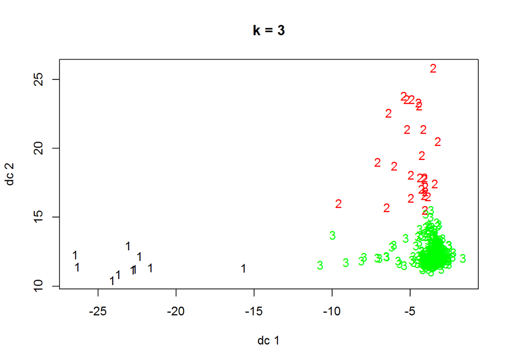

```r
plotcluster(interests, sp500_clusters_3$cluster, main="k = 3") #creates a visualization of the K=3 cluster. Are there distinct groups?
```

### What about k=4?

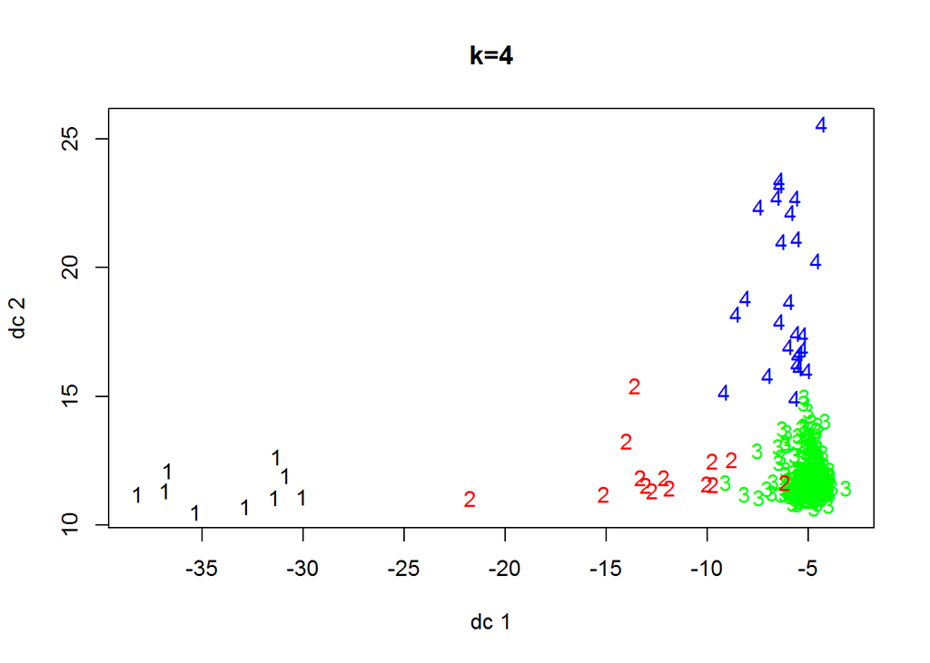

```r
set.seed(123)
sp500_clusters_4 <- kmeans(interests, centers=4)
plotcluster(interests, sp500_clusters_4$cluster, main="k=4")
```

```r
sp500_clusters_4$size
```

```
## [1]   9  14 393  26
```

```r
t(sp500_clusters_4$centers) #transpose for ease of reading purpose
```

```
##                                        1             2            3
## Dividend.Yield               1.778888889   1.389285714  1.873078880
## Earnings.Share               0.704444444   0.820000000  3.471017812
## Book.Value                  18.134444444   3.906428571 25.169389313
## Market.Cap                  32.922222222  36.513571429 25.877404580
## EBITDA                       3.169322222   3.135285714  2.389189746
## Gross.Margin                49.444444444  60.857142857 46.033078880
## Operating.Margin            79.000000000  87.928571429 17.643765903
## Pre.Tax.ROE                854.000000000 265.642857143 27.707379135
## Cash.and.Cash.Equivalents    0.001321579   0.002331436  0.005163139
## Net.Cash.Flow.Operating      0.048453278   0.061860771  0.052907748
## Sale.and.Purchase.of.Stock   0.854677634   0.851049868  0.849634094
## Total.Assets                 0.005305603   0.007118355  0.014420183
## Total.Equity                 0.050949077   0.057549892  0.079424903
## Total.Liabilities            0.006251707   0.007446568  0.012805523
## Total.Revenue                0.018780464   0.025340532  0.029336629
##                                      4
## Dividend.Yield               2.5176923
## Earnings.Share               3.9680769
## Book.Value                  24.5661538
## Market.Cap                 256.0765385
## EBITDA                      18.6592308
## Gross.Margin                52.6538462
## Operating.Margin            19.5000000
## Pre.Tax.ROE                 40.2307692
## Cash.and.Cash.Equivalents    0.1302855
## Net.Cash.Flow.Operating      0.2972303
## Sale.and.Purchase.of.Stock   0.7675376
## Total.Assets                 0.1814105
## Total.Equity                 0.3502453
## Total.Liabilities            0.1648866
## Total.Revenue                0.2139889
```

### What about k=5?

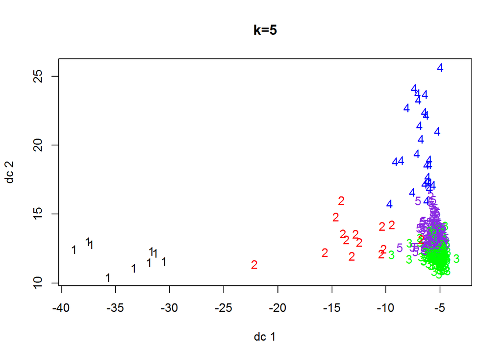

```r
set.seed(123)
sp500_clusters_5 <- kmeans(interests, centers=5)
plotcluster(interests, sp500_clusters_5$cluster, main="k=5")
```

```r
sp500_clusters_5$size
```

```
## [1]   9  14 233  26 160
```

```r
t(sp500_clusters_5$centers) #transpose for ease of reading purpose
```

```
##                                        1             2            3
## Dividend.Yield               1.778888889   1.389285714  1.907467811
## Earnings.Share               0.704444444   0.820000000  3.626566524
## Book.Value                  18.134444444   3.906428571 28.281158798
## Market.Cap                  32.922222222  36.513571429 22.850343348
## EBITDA                       3.169322222   3.135285714  2.304772961
## Gross.Margin                49.444444444  60.857142857 29.399141631
## Operating.Margin            79.000000000  87.928571429 10.982832618
## Pre.Tax.ROE                854.000000000 265.642857143 25.879828326
## Cash.and.Cash.Equivalents    0.001321579   0.002331436  0.006259374
## Net.Cash.Flow.Operating      0.048453278   0.061860771  0.053990239
## Sale.and.Purchase.of.Stock   0.854677634   0.851049868  0.847861672
## Total.Assets                 0.005305603   0.007118355  0.017919847
## Total.Equity                 0.050949077   0.057549892  0.081749106
## Total.Liabilities            0.006251707   0.007446568  0.016420599
## Total.Revenue                0.018780464   0.025340532  0.039020742
##                                      4            5
## Dividend.Yield               2.5176923  1.823000000
## Earnings.Share               3.9680769  3.244500000
## Book.Value                  24.5661538 20.637875000
## Market.Cap                 256.0765385 30.285562500
## EBITDA                      18.6592308  2.512121687
## Gross.Margin                52.6538462 70.256250000
## Operating.Margin            19.5000000 27.343750000
## Pre.Tax.ROE                 40.2307692 30.368750000
## Cash.and.Cash.Equivalents    0.1302855  0.003566748
## Net.Cash.Flow.Operating      0.2972303  0.051331370
## Sale.and.Purchase.of.Stock   0.7675376  0.852215182
## Total.Assets                 0.1814105  0.009323797
## Total.Equity                 0.3502453  0.076040282
## Total.Liabilities            0.1648866  0.007541068
## Total.Revenue                0.2139889  0.015234140
```

### What about k=6?

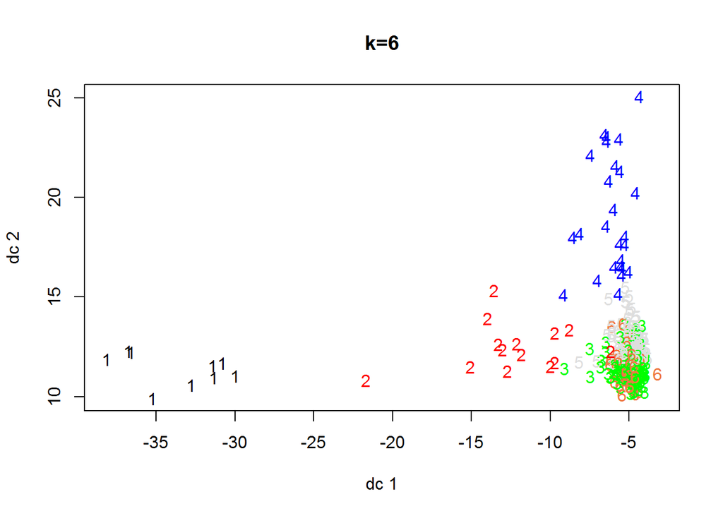

```r
set.seed(123)
sp500_clusters_6 <- kmeans(interests, centers=6)
plotcluster(interests, sp500_clusters_6$cluster, main="k=6")
```

```r
sp500_clusters_6$size
```

```
## [1]   9  14 193  26 135  65
```

```r
t(sp500_clusters_6$centers) #transpose for ease of reading purpose
```

```
##                                        1             2            3
## Dividend.Yield               1.778888889   1.389285714  1.932487047
## Earnings.Share               0.704444444   0.820000000  2.960466321
## Book.Value                  18.134444444   3.906428571 19.631191710
## Market.Cap                  32.922222222  36.513571429 21.668860104
## EBITDA                       3.169322222   3.135285714  2.214771710
## Gross.Margin                49.444444444  60.857142857 28.471502591
## Operating.Margin            79.000000000  87.928571429 10.746113990
## Pre.Tax.ROE                854.000000000 265.642857143 30.119170984
## Cash.and.Cash.Equivalents    0.001321579   0.002331436  0.005466348
## Net.Cash.Flow.Operating      0.048453278   0.061860771  0.051751310
## Sale.and.Purchase.of.Stock   0.854677634   0.851049868  0.848914257
## Total.Assets                 0.005305603   0.007118355  0.011821251
## Total.Equity                 0.050949077   0.057549892  0.074331118
## Total.Liabilities            0.006251707   0.007446568  0.010545978
## Total.Revenue                0.018780464   0.025340532  0.039004866
##                                      4            5            6
## Dividend.Yield               2.5176923  1.816518519  1.814153846
## Earnings.Share               3.9680769  3.205925926  5.537538462
## Book.Value                  24.5661538 16.149555556 60.347076923
## Market.Cap                 256.0765385 30.307703704 29.172153846
## EBITDA                      18.6592308  2.495420296  2.686444462
## Gross.Margin                52.6538462 72.000000000 44.246153846
## Operating.Margin            19.5000000 28.207407407 16.184615385
## Pre.Tax.ROE                 40.2307692 30.970370370 13.769230769
## Cash.and.Cash.Equivalents    0.1302855  0.003991363  0.006696534
## Net.Cash.Flow.Operating      0.2972303  0.051374195  0.059526549
## Sale.and.Purchase.of.Stock   0.7675376  0.850080726  0.850843832
## Total.Assets                 0.1814105  0.009461615  0.032435575
## Total.Equity                 0.3502453  0.075482749  0.102737079
## Total.Liabilities            0.1648866  0.007766488  0.029980320
## Total.Revenue                0.2139889  0.015088681  0.030221295
```

### What about k=7?

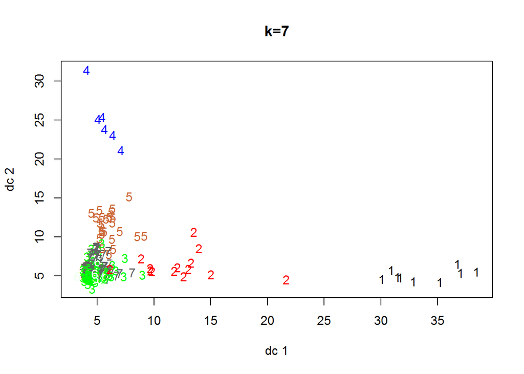

```r
set.seed(123)
sp500_clusters_7 <- kmeans(interests, centers=7)
plotcluster(interests, sp500_clusters_7$cluster, main="k=7")
```

```r
sp500_clusters_7$size
```

```
## [1]   9  14 207   6  25  41 140
```

```r
t(sp500_clusters_7$centers) #transpose for ease of reading purpose
```

```
##                                        1             2            3
## Dividend.Yield               1.778888889   1.389285714  1.942801932
## Earnings.Share               0.704444444   0.820000000  2.961014493
## Book.Value                  18.134444444   3.906428571 21.846521739
## Market.Cap                  32.922222222  36.513571429 21.570966184
## EBITDA                       3.169322222   3.135285714  2.227383382
## Gross.Margin                49.444444444  60.857142857 29.169082126
## Operating.Margin            79.000000000  87.928571429 11.154589372
## Pre.Tax.ROE                854.000000000 265.642857143 27.888888889
## Cash.and.Cash.Equivalents    0.001321579   0.002331436  0.005167632
## Net.Cash.Flow.Operating      0.048453278   0.061860771  0.051572452
## Sale.and.Purchase.of.Stock   0.854677634   0.851049868  0.849089840
## Total.Assets                 0.005305603   0.007118355  0.012220730
## Total.Equity                 0.050949077   0.057549892  0.075920510
## Total.Liabilities            0.006251707   0.007446568  0.010791074
## Total.Revenue                0.018780464   0.025340532  0.037274610
##                                      4           5            6
## Dividend.Yield               1.6283333   2.7028000  1.668536585
## Earnings.Share               4.4850000   4.4560000  7.587804878
## Book.Value                  33.2400000  20.0348000 72.639756098
## Market.Cap                 449.6333333 181.5816000 33.118536585
## EBITDA                      24.5400000  15.3148000  2.847636098
## Gross.Margin                59.6666667  51.7600000 44.560975610
## Operating.Margin            20.8333333  21.3200000 15.024390244
## Pre.Tax.ROE                 22.5000000  51.4400000 13.414634146
## Cash.and.Cash.Equivalents    0.1457084   0.1023258  0.009737983
## Net.Cash.Flow.Operating      0.5006700   0.2119180  0.063826370
## Sale.and.Purchase.of.Stock   0.6479894   0.7938055  0.847570746
## Total.Assets                 0.2310886   0.1373880  0.042859351
## Total.Equity                 0.4674502   0.2706648  0.111439646
## Total.Liabilities            0.2052763   0.1258817  0.040522210
## Total.Revenue                0.2736562   0.1716599  0.036499299
##                                       7
## Dividend.Yield              1.811928571
## Earnings.Share              2.892428571
## Book.Value                 16.639428571
## Market.Cap                 26.910142857
## EBITDA                      2.258286643
## Gross.Margin               71.021428571
## Operating.Margin           27.557142857
## Pre.Tax.ROE                29.935714286
## Cash.and.Cash.Equivalents   0.003679888
## Net.Cash.Flow.Operating     0.049474177
## Sale.and.Purchase.of.Stock  0.854407911
## Total.Assets                0.009111790
## Total.Equity                0.074746241
## Total.Liabilities           0.007469702
## Total.Revenue               0.013908982
```

### What about k=8?

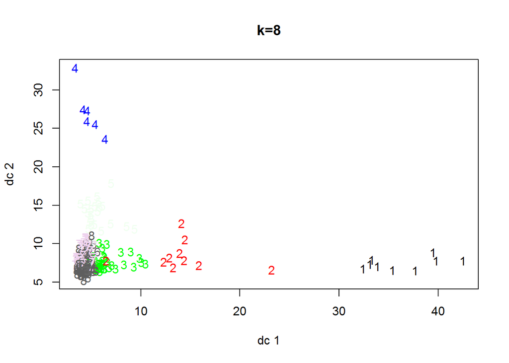

```r
set.seed(123)
sp500_clusters_8 <- kmeans(interests, centers=8)
plotcluster(interests, sp500_clusters_8$cluster, main="k=8")
```

```r
sp500_clusters_8$size
```

```
## [1]   9  10  36   6  23  41 126 191
```

```r
t(sp500_clusters_8$centers) #transpose for ease of reading purpose
```

```
##                                        1             2            3
## Dividend.Yield               1.778888889   1.166000000  2.021666667
## Earnings.Share               0.704444444  -0.503000000  5.871944444
## Book.Value                  18.134444444   4.322000000  4.175277778
## Market.Cap                  32.922222222  33.994000000 33.476666667
## EBITDA                       3.169322222   2.515400000  3.851640000
## Gross.Margin                49.444444444  61.400000000 44.527777778
## Operating.Margin            79.000000000 108.500000000 23.222222222
## Pre.Tax.ROE                854.000000000 299.800000000 96.972222222
## Cash.and.Cash.Equivalents    0.001321579   0.001910107  0.002676154
## Net.Cash.Flow.Operating      0.048453278   0.058063159  0.065791213
## Sale.and.Purchase.of.Stock   0.854677634   0.864406757  0.820014059
## Total.Assets                 0.005305603   0.005384359  0.008362132
## Total.Equity                 0.050949077   0.055860697  0.062240474
## Total.Liabilities            0.006251707   0.005723684  0.008236268
## Total.Revenue                0.018780464   0.023070045  0.036586534
##                                      4           5            6
## Dividend.Yield               1.6283333   2.6743478  1.668536585
## Earnings.Share               4.4850000   4.2760870  7.587804878
## Book.Value                  33.2400000  21.8365217 72.639756098
## Market.Cap                 449.6333333 187.9639130 33.118536585
## EBITDA                      24.5400000  15.8630435  2.847636098
## Gross.Margin                59.6666667  53.9130435 44.560975610
## Operating.Margin            20.8333333  21.6086957 15.024390244
## Pre.Tax.ROE                 22.5000000  47.0000000 13.414634146
## Cash.and.Cash.Equivalents    0.1457084   0.1100675  0.009737983
## Net.Cash.Flow.Operating      0.5006700   0.2196026  0.063826370
## Sale.and.Purchase.of.Stock   0.6479894   0.8007509  0.847570746
## Total.Assets                 0.2310886   0.1469392  0.042859351
## Total.Equity                 0.4674502   0.2877559  0.111439646
## Total.Liabilities            0.2052763   0.1343781  0.040522210
## Total.Revenue                0.2736562   0.1758315  0.036499299
##                                       7            8
## Dividend.Yield              1.874285714  1.888691099
## Earnings.Share              2.298333333  2.860994764
## Book.Value                 18.203333333 23.130471204
## Market.Cap                 26.715079365 21.198795812
## EBITDA                      2.052316587  2.181872042
## Gross.Margin               72.230158730 29.157068063
## Operating.Margin           27.079365079 11.000000000
## Pre.Tax.ROE                23.650793651 23.136125654
## Cash.and.Cash.Equivalents   0.003811966  0.005488827
## Net.Cash.Flow.Operating     0.047463269  0.051233173
## Sale.and.Purchase.of.Stock  0.858060049  0.850477116
## Total.Assets                0.009232456  0.012784953
## Total.Equity                0.075839088  0.077376764
## Total.Liabilities           0.007464371  0.011234851
## Total.Revenue               0.012449274  0.037428364
```

### What about k=9?

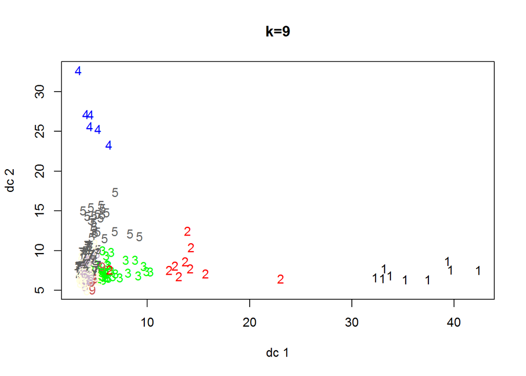

```r
set.seed(123)
sp500_clusters_9 <- kmeans(interests, centers=9)
plotcluster(interests, sp500_clusters_9$cluster, main="k=9")
```

```r
sp500_clusters_9$size
```

```
## [1]   9  10  36   6  23  70 111 164  13
```

```r
t(sp500_clusters_9$centers) #transpose for ease of reading purpose
```

```
##                                        1             2            3
## Dividend.Yield               1.778888889   1.166000000  2.021666667
## Earnings.Share               0.704444444  -0.503000000  5.871944444
## Book.Value                  18.134444444   4.322000000  4.175277778
## Market.Cap                  32.922222222  33.994000000 33.476666667
## EBITDA                       3.169322222   2.515400000  3.851640000
## Gross.Margin                49.444444444  61.400000000 44.527777778
## Operating.Margin            79.000000000 108.500000000 23.222222222
## Pre.Tax.ROE                854.000000000 299.800000000 96.972222222
## Cash.and.Cash.Equivalents    0.001321579   0.001910107  0.002676154
## Net.Cash.Flow.Operating      0.048453278   0.058063159  0.065791213
## Sale.and.Purchase.of.Stock   0.854677634   0.864406757  0.820014059
## Total.Assets                 0.005305603   0.005384359  0.008362132
## Total.Equity                 0.050949077   0.055860697  0.062240474
## Total.Liabilities            0.006251707   0.005723684  0.008236268
## Total.Revenue                0.018780464   0.023070045  0.036586534
##                                      4           5            6
## Dividend.Yield               1.6283333   2.6743478  2.063571429
## Earnings.Share               4.4850000   4.2760870  3.343285714
## Book.Value                  33.2400000  21.8365217 45.357714286
## Market.Cap                 449.6333333 187.9639130 22.293142857
## EBITDA                      24.5400000  15.8630435  2.384142000
## Gross.Margin                59.6666667  53.9130435 48.342857143
## Operating.Margin            20.8333333  21.6086957 18.042857143
## Pre.Tax.ROE                 22.5000000  47.0000000 13.642857143
## Cash.and.Cash.Equivalents    0.1457084   0.1100675  0.001426669
## Net.Cash.Flow.Operating      0.5006700   0.2196026  0.052944576
## Sale.and.Purchase.of.Stock   0.6479894   0.8007509  0.862852426
## Total.Assets                 0.2310886   0.1469392  0.018861740
## Total.Equity                 0.4674502   0.2877559  0.086373013
## Total.Liabilities            0.2052763   0.1343781  0.016881305
## Total.Revenue                0.2736562   0.1758315  0.019356527
##                                       7            8            9
## Dividend.Yield              1.746846847  1.876036585   1.48384615
## Earnings.Share              2.478648649  2.787195122  13.91384615
## Book.Value                 16.027297297 20.653170732 103.73692308
## Market.Cap                 27.506216216 21.930121951  43.28307692
## EBITDA                      2.024701802  2.208307988   2.94524462
## Gross.Margin               73.945945946 27.097560976  35.46153846
## Operating.Margin           27.297297297 10.164634146  13.00000000
## Pre.Tax.ROE                25.153153153 24.378048780  15.69230769
## Cash.and.Cash.Equivalents   0.004191750  0.006225295   0.02629472
## Net.Cash.Flow.Operating     0.047026707  0.051626656   0.07614868
## Sale.and.Purchase.of.Stock  0.856294391  0.848739079   0.82042613
## Total.Assets                0.009092948  0.012306981   0.07803576
## Total.Equity                0.074405205  0.077189359   0.14919760
## Total.Liabilities           0.007492031  0.010723517   0.07506263
## Total.Revenue               0.012502609  0.041130178   0.05583089
```

#### Examine the betweenss and withinss ratios!

We want the clusters to demonstrate both cohesion and separation. Cohesion is measured by minimizing the ratio of withinss/totalss. Separation is measured by maximizing the ratio of betweenss/totalss.

##### Cluster Separation

```r
clusters3<- sp500_clusters_3$betweenss/sp500_clusters_3$totss
clusters4<- sp500_clusters_4$betweenss/sp500_clusters_4$totss
clusters5<- sp500_clusters_5$betweenss/sp500_clusters_5$totss
clusters6<- sp500_clusters_6$betweenss/sp500_clusters_6$totss
clusters7<- sp500_clusters_7$betweenss/sp500_clusters_7$totss
clusters8<- sp500_clusters_8$betweenss/sp500_clusters_8$totss
clusters9<- sp500_clusters_9$betweenss/sp500_clusters_9$totss

betweenss.metric <- c(clusters3, clusters4, clusters5, clusters6, clusters7, clusters8, clusters9)
print(betweenss.metric) #Look for a ratio that is closer to 1.
```

```
## [1] 0.7226899 0.7934258 0.8127400 0.8224078 0.8532324 0.8664625 0.8697944
```

*Cluster Separation* : *| 0.7226899 | 0.7934258 | 0.8127400 | 0.8224078 | 0.8532324 | 0.8664625 | 0.8697944 |*

##### Cluster Cohesion

```r
clusters3<- sp500_clusters_3$tot.withinss/sp500_clusters_3$totss
clusters4<- sp500_clusters_4$tot.withinss/sp500_clusters_4$totss
clusters5<- sp500_clusters_5$tot.withinss/sp500_clusters_5$totss
clusters6<- sp500_clusters_6$tot.withinss/sp500_clusters_6$totss
clusters7<- sp500_clusters_7$tot.withinss/sp500_clusters_7$totss
clusters8<- sp500_clusters_8$tot.withinss/sp500_clusters_8$totss
clusters9<- sp500_clusters_9$tot.withinss/sp500_clusters_9$totss

totwithinss.metric <- c(clusters3, clusters4, clusters5, clusters6, clusters7, clusters8, clusters9)
print(totwithinss.metric) #Looking for a ratio that is closer to 0.
```

```
## [1] 0.2773101 0.2065742 0.1872600 0.1775922 0.1467676 0.1335375 0.1302056
```

*Cluster Cohesion* *| 0.2773101 | 0.2065742 | 0.1872600 | 0.1775922 | 0.1467676 | 0.1335375 | 0.1302056 |*

#### Using the “Elbow Method” for cross validation

**The elbow method looks at the percentage of variance explained as a function of the number of clusters: One should choose a number of clusters so that adding another cluster doesn’t give much better modeling of the data.**

##### Withinss

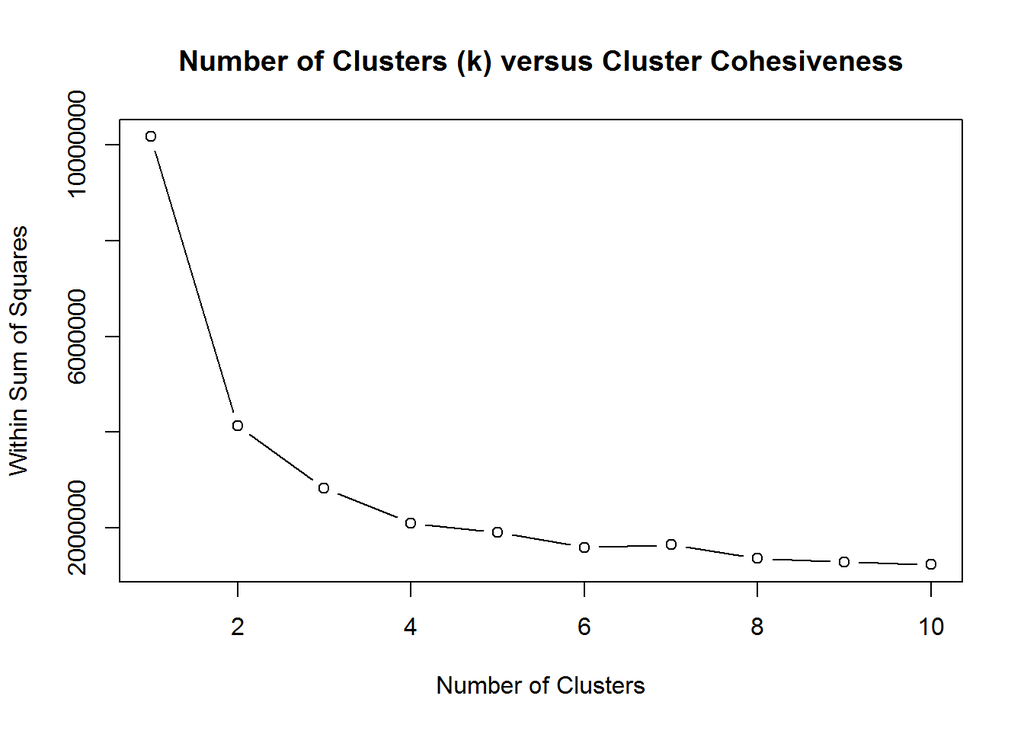

```r
#WithinSS
wss <- (nrow(interests)-1)*sum(apply(interests,2,var))
for (i in 2:10) wss[i] <- sum(kmeans(interests,
                                     centers=i)$withinss)
plot(1:10, wss, type="b", xlab="Number of Clusters",
     ylab="Within Sum of Squares", main = "Number of Clusters (k) versus Cluster Cohesiveness")
```

##### BetweenSS

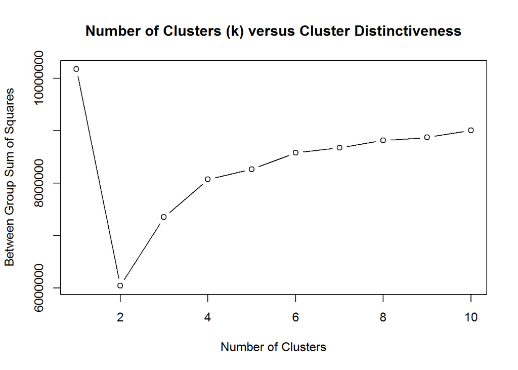

```r
#BetweenSS
wss <- (nrow(interests)-1)*sum(apply(interests,2,var))
for (i in 2:10) wss[i] <- sum(kmeans(interests,
                                     centers=i)$betweenss)
plot(1:10, wss, type="b", xlab="Number of Clusters",
     ylab="Between Group Sum of Squares", main = "Number of Clusters (k) versus Cluster Distinctiveness")
```

# Creating an Aggregate Profile for Our Clusters

Compare cluster 5, 6 and 7 to validate which one is good fit for final analysis. We can sort the centroids for each cluster to see what financial ratios are significan in each groups

## cluster 5 details review

```r
sp500_clusters_5$size #Get the size of each cluster
```

```
## [1]   9  14 233  26 160
```

```r
Clusters_5<-data.frame(t(sp500_clusters_5$centers)) #Transpose for easier reading

Clusters_5[order(-Clusters_5$X1), ]
```

```
##                                       X1            X2           X3
## Pre.Tax.ROE                854.000000000 265.642857143 25.879828326
## Operating.Margin            79.000000000  87.928571429 10.982832618
## Gross.Margin                49.444444444  60.857142857 29.399141631
## Market.Cap                  32.922222222  36.513571429 22.850343348
## Book.Value                  18.134444444   3.906428571 28.281158798
## EBITDA                       3.169322222   3.135285714  2.304772961
## Dividend.Yield               1.778888889   1.389285714  1.907467811
## Sale.and.Purchase.of.Stock   0.854677634   0.851049868  0.847861672
## Earnings.Share               0.704444444   0.820000000  3.626566524
## Total.Equity                 0.050949077   0.057549892  0.081749106
## Net.Cash.Flow.Operating      0.048453278   0.061860771  0.053990239
## Total.Revenue                0.018780464   0.025340532  0.039020742
## Total.Liabilities            0.006251707   0.007446568  0.016420599
## Total.Assets                 0.005305603   0.007118355  0.017919847
## Cash.and.Cash.Equivalents    0.001321579   0.002331436  0.006259374
##                                     X4           X5
## Pre.Tax.ROE                 40.2307692 30.368750000
## Operating.Margin            19.5000000 27.343750000
## Gross.Margin                52.6538462 70.256250000
## Market.Cap                 256.0765385 30.285562500
## Book.Value                  24.5661538 20.637875000
## EBITDA                      18.6592308  2.512121687
## Dividend.Yield               2.5176923  1.823000000
## Sale.and.Purchase.of.Stock   0.7675376  0.852215182
## Earnings.Share               3.9680769  3.244500000
## Total.Equity                 0.3502453  0.076040282
## Net.Cash.Flow.Operating      0.2972303  0.051331370
## Total.Revenue                0.2139889  0.015234140
## Total.Liabilities            0.1648866  0.007541068
## Total.Assets                 0.1814105  0.009323797
## Cash.and.Cash.Equivalents    0.1302855  0.003566748
```

```r
Clusters_5[order(-Clusters_5$X2), ]
```

```
##                                       X1            X2           X3
## Pre.Tax.ROE                854.000000000 265.642857143 25.879828326
## Operating.Margin            79.000000000  87.928571429 10.982832618
## Gross.Margin                49.444444444  60.857142857 29.399141631
## Market.Cap                  32.922222222  36.513571429 22.850343348
## Book.Value                  18.134444444   3.906428571 28.281158798
## EBITDA                       3.169322222   3.135285714  2.304772961
## Dividend.Yield               1.778888889   1.389285714  1.907467811
## Sale.and.Purchase.of.Stock   0.854677634   0.851049868  0.847861672
## Earnings.Share               0.704444444   0.820000000  3.626566524
## Net.Cash.Flow.Operating      0.048453278   0.061860771  0.053990239
## Total.Equity                 0.050949077   0.057549892  0.081749106
## Total.Revenue                0.018780464   0.025340532  0.039020742
## Total.Liabilities            0.006251707   0.007446568  0.016420599
## Total.Assets                 0.005305603   0.007118355  0.017919847
## Cash.and.Cash.Equivalents    0.001321579   0.002331436  0.006259374
##                                     X4           X5
## Pre.Tax.ROE                 40.2307692 30.368750000
## Operating.Margin            19.5000000 27.343750000
## Gross.Margin                52.6538462 70.256250000
## Market.Cap                 256.0765385 30.285562500
## Book.Value                  24.5661538 20.637875000
## EBITDA                      18.6592308  2.512121687
## Dividend.Yield               2.5176923  1.823000000
## Sale.and.Purchase.of.Stock   0.7675376  0.852215182
## Earnings.Share               3.9680769  3.244500000
## Net.Cash.Flow.Operating      0.2972303  0.051331370
## Total.Equity                 0.3502453  0.076040282
## Total.Revenue                0.2139889  0.015234140
## Total.Liabilities            0.1648866  0.007541068
## Total.Assets                 0.1814105  0.009323797
## Cash.and.Cash.Equivalents    0.1302855  0.003566748
```

```r
Clusters_5[order(-Clusters_5$X3), ]
```

```
##                                       X1            X2           X3
## Gross.Margin                49.444444444  60.857142857 29.399141631
## Book.Value                  18.134444444   3.906428571 28.281158798
## Pre.Tax.ROE                854.000000000 265.642857143 25.879828326
## Market.Cap                  32.922222222  36.513571429 22.850343348
## Operating.Margin            79.000000000  87.928571429 10.982832618
## Earnings.Share               0.704444444   0.820000000  3.626566524
## EBITDA                       3.169322222   3.135285714  2.304772961
## Dividend.Yield               1.778888889   1.389285714  1.907467811
## Sale.and.Purchase.of.Stock   0.854677634   0.851049868  0.847861672
## Total.Equity                 0.050949077   0.057549892  0.081749106
## Net.Cash.Flow.Operating      0.048453278   0.061860771  0.053990239
## Total.Revenue                0.018780464   0.025340532  0.039020742
## Total.Assets                 0.005305603   0.007118355  0.017919847
## Total.Liabilities            0.006251707   0.007446568  0.016420599
## Cash.and.Cash.Equivalents    0.001321579   0.002331436  0.006259374
##                                     X4           X5
## Gross.Margin                52.6538462 70.256250000
## Book.Value                  24.5661538 20.637875000
## Pre.Tax.ROE                 40.2307692 30.368750000
## Market.Cap                 256.0765385 30.285562500
## Operating.Margin            19.5000000 27.343750000
## Earnings.Share               3.9680769  3.244500000
## EBITDA                      18.6592308  2.512121687
## Dividend.Yield               2.5176923  1.823000000
## Sale.and.Purchase.of.Stock   0.7675376  0.852215182
## Total.Equity                 0.3502453  0.076040282
## Net.Cash.Flow.Operating      0.2972303  0.051331370
## Total.Revenue                0.2139889  0.015234140
## Total.Assets                 0.1814105  0.009323797
## Total.Liabilities            0.1648866  0.007541068
## Cash.and.Cash.Equivalents    0.1302855  0.003566748
```

```r
Clusters_5[order(-Clusters_5$X4), ]
```

```
##                                       X1            X2           X3
## Market.Cap                  32.922222222  36.513571429 22.850343348
## Gross.Margin                49.444444444  60.857142857 29.399141631
## Pre.Tax.ROE                854.000000000 265.642857143 25.879828326
## Book.Value                  18.134444444   3.906428571 28.281158798
## Operating.Margin            79.000000000  87.928571429 10.982832618
## EBITDA                       3.169322222   3.135285714  2.304772961
## Earnings.Share               0.704444444   0.820000000  3.626566524
## Dividend.Yield               1.778888889   1.389285714  1.907467811
## Sale.and.Purchase.of.Stock   0.854677634   0.851049868  0.847861672
## Total.Equity                 0.050949077   0.057549892  0.081749106
## Net.Cash.Flow.Operating      0.048453278   0.061860771  0.053990239
## Total.Revenue                0.018780464   0.025340532  0.039020742
## Total.Assets                 0.005305603   0.007118355  0.017919847
## Total.Liabilities            0.006251707   0.007446568  0.016420599
## Cash.and.Cash.Equivalents    0.001321579   0.002331436  0.006259374
##                                     X4           X5
## Market.Cap                 256.0765385 30.285562500
## Gross.Margin                52.6538462 70.256250000
## Pre.Tax.ROE                 40.2307692 30.368750000
## Book.Value                  24.5661538 20.637875000
## Operating.Margin            19.5000000 27.343750000
## EBITDA                      18.6592308  2.512121687
## Earnings.Share               3.9680769  3.244500000
## Dividend.Yield               2.5176923  1.823000000
## Sale.and.Purchase.of.Stock   0.7675376  0.852215182
## Total.Equity                 0.3502453  0.076040282
## Net.Cash.Flow.Operating      0.2972303  0.051331370
## Total.Revenue                0.2139889  0.015234140
## Total.Assets                 0.1814105  0.009323797
## Total.Liabilities            0.1648866  0.007541068
## Cash.and.Cash.Equivalents    0.1302855  0.003566748
```

```r
Clusters_5[order(-Clusters_5$X5), ]
```

```
##                                       X1            X2           X3
## Gross.Margin                49.444444444  60.857142857 29.399141631
## Pre.Tax.ROE                854.000000000 265.642857143 25.879828326
## Market.Cap                  32.922222222  36.513571429 22.850343348
## Operating.Margin            79.000000000  87.928571429 10.982832618
## Book.Value                  18.134444444   3.906428571 28.281158798
## Earnings.Share               0.704444444   0.820000000  3.626566524
## EBITDA                       3.169322222   3.135285714  2.304772961
## Dividend.Yield               1.778888889   1.389285714  1.907467811
## Sale.and.Purchase.of.Stock   0.854677634   0.851049868  0.847861672
## Total.Equity                 0.050949077   0.057549892  0.081749106
## Net.Cash.Flow.Operating      0.048453278   0.061860771  0.053990239
## Total.Revenue                0.018780464   0.025340532  0.039020742
## Total.Assets                 0.005305603   0.007118355  0.017919847
## Total.Liabilities            0.006251707   0.007446568  0.016420599
## Cash.and.Cash.Equivalents    0.001321579   0.002331436  0.006259374
##                                     X4           X5
## Gross.Margin                52.6538462 70.256250000
## Pre.Tax.ROE                 40.2307692 30.368750000
## Market.Cap                 256.0765385 30.285562500
## Operating.Margin            19.5000000 27.343750000
## Book.Value                  24.5661538 20.637875000
## Earnings.Share               3.9680769  3.244500000
## EBITDA                      18.6592308  2.512121687
## Dividend.Yield               2.5176923  1.823000000
## Sale.and.Purchase.of.Stock   0.7675376  0.852215182
## Total.Equity                 0.3502453  0.076040282
## Net.Cash.Flow.Operating      0.2972303  0.051331370
## Total.Revenue                0.2139889  0.015234140
## Total.Assets                 0.1814105  0.009323797
## Total.Liabilities            0.1648866  0.007541068
## Cash.and.Cash.Equivalents    0.1302855  0.003566748
```

## cluster 6 details review

```r
sp500_clusters_6$size #Get the size of each cluster
```

```
## [1]   9  14 193  26 135  65
```

```r
Clusters_6<-data.frame(t(sp500_clusters_6$centers)) #Transpose for easier reading

Clusters_6[order(-Clusters_6$X1), ]
```

```
##                                       X1            X2           X3
## Pre.Tax.ROE                854.000000000 265.642857143 30.119170984
## Operating.Margin            79.000000000  87.928571429 10.746113990
## Gross.Margin                49.444444444  60.857142857 28.471502591
## Market.Cap                  32.922222222  36.513571429 21.668860104
## Book.Value                  18.134444444   3.906428571 19.631191710
## EBITDA                       3.169322222   3.135285714  2.214771710
## Dividend.Yield               1.778888889   1.389285714  1.932487047
## Sale.and.Purchase.of.Stock   0.854677634   0.851049868  0.848914257
## Earnings.Share               0.704444444   0.820000000  2.960466321
## Total.Equity                 0.050949077   0.057549892  0.074331118
## Net.Cash.Flow.Operating      0.048453278   0.061860771  0.051751310
## Total.Revenue                0.018780464   0.025340532  0.039004866
## Total.Liabilities            0.006251707   0.007446568  0.010545978
## Total.Assets                 0.005305603   0.007118355  0.011821251
## Cash.and.Cash.Equivalents    0.001321579   0.002331436  0.005466348
##                                     X4           X5           X6
## Pre.Tax.ROE                 40.2307692 30.970370370 13.769230769
## Operating.Margin            19.5000000 28.207407407 16.184615385
## Gross.Margin                52.6538462 72.000000000 44.246153846
## Market.Cap                 256.0765385 30.307703704 29.172153846
## Book.Value                  24.5661538 16.149555556 60.347076923
## EBITDA                      18.6592308  2.495420296  2.686444462
## Dividend.Yield               2.5176923  1.816518519  1.814153846
## Sale.and.Purchase.of.Stock   0.7675376  0.850080726  0.850843832
## Earnings.Share               3.9680769  3.205925926  5.537538462
## Total.Equity                 0.3502453  0.075482749  0.102737079
## Net.Cash.Flow.Operating      0.2972303  0.051374195  0.059526549
## Total.Revenue                0.2139889  0.015088681  0.030221295
## Total.Liabilities            0.1648866  0.007766488  0.029980320
## Total.Assets                 0.1814105  0.009461615  0.032435575
## Cash.and.Cash.Equivalents    0.1302855  0.003991363  0.006696534
```

```r
Clusters_6[order(-Clusters_6$X2), ]
```

```
##                                       X1            X2           X3
## Pre.Tax.ROE                854.000000000 265.642857143 30.119170984
## Operating.Margin            79.000000000  87.928571429 10.746113990
## Gross.Margin                49.444444444  60.857142857 28.471502591
## Market.Cap                  32.922222222  36.513571429 21.668860104
## Book.Value                  18.134444444   3.906428571 19.631191710
## EBITDA                       3.169322222   3.135285714  2.214771710
## Dividend.Yield               1.778888889   1.389285714  1.932487047
## Sale.and.Purchase.of.Stock   0.854677634   0.851049868  0.848914257
## Earnings.Share               0.704444444   0.820000000  2.960466321
## Net.Cash.Flow.Operating      0.048453278   0.061860771  0.051751310
## Total.Equity                 0.050949077   0.057549892  0.074331118
## Total.Revenue                0.018780464   0.025340532  0.039004866
## Total.Liabilities            0.006251707   0.007446568  0.010545978
## Total.Assets                 0.005305603   0.007118355  0.011821251
## Cash.and.Cash.Equivalents    0.001321579   0.002331436  0.005466348
##                                     X4           X5           X6
## Pre.Tax.ROE                 40.2307692 30.970370370 13.769230769
## Operating.Margin            19.5000000 28.207407407 16.184615385
## Gross.Margin                52.6538462 72.000000000 44.246153846
## Market.Cap                 256.0765385 30.307703704 29.172153846
## Book.Value                  24.5661538 16.149555556 60.347076923
## EBITDA                      18.6592308  2.495420296  2.686444462
## Dividend.Yield               2.5176923  1.816518519  1.814153846
## Sale.and.Purchase.of.Stock   0.7675376  0.850080726  0.850843832
## Earnings.Share               3.9680769  3.205925926  5.537538462
## Net.Cash.Flow.Operating      0.2972303  0.051374195  0.059526549
## Total.Equity                 0.3502453  0.075482749  0.102737079
## Total.Revenue                0.2139889  0.015088681  0.030221295
## Total.Liabilities            0.1648866  0.007766488  0.029980320
## Total.Assets                 0.1814105  0.009461615  0.032435575
## Cash.and.Cash.Equivalents    0.1302855  0.003991363  0.006696534
```

```r
Clusters_6[order(-Clusters_6$X3), ]
```

```
##                                       X1            X2           X3
## Pre.Tax.ROE                854.000000000 265.642857143 30.119170984
## Gross.Margin                49.444444444  60.857142857 28.471502591
## Market.Cap                  32.922222222  36.513571429 21.668860104
## Book.Value                  18.134444444   3.906428571 19.631191710
## Operating.Margin            79.000000000  87.928571429 10.746113990
## Earnings.Share               0.704444444   0.820000000  2.960466321
## EBITDA                       3.169322222   3.135285714  2.214771710
## Dividend.Yield               1.778888889   1.389285714  1.932487047
## Sale.and.Purchase.of.Stock   0.854677634   0.851049868  0.848914257
## Total.Equity                 0.050949077   0.057549892  0.074331118
## Net.Cash.Flow.Operating      0.048453278   0.061860771  0.051751310
## Total.Revenue                0.018780464   0.025340532  0.039004866
## Total.Assets                 0.005305603   0.007118355  0.011821251
## Total.Liabilities            0.006251707   0.007446568  0.010545978
## Cash.and.Cash.Equivalents    0.001321579   0.002331436  0.005466348
##                                     X4           X5           X6
## Pre.Tax.ROE                 40.2307692 30.970370370 13.769230769
## Gross.Margin                52.6538462 72.000000000 44.246153846
## Market.Cap                 256.0765385 30.307703704 29.172153846
## Book.Value                  24.5661538 16.149555556 60.347076923
## Operating.Margin            19.5000000 28.207407407 16.184615385
## Earnings.Share               3.9680769  3.205925926  5.537538462
## EBITDA                      18.6592308  2.495420296  2.686444462
## Dividend.Yield               2.5176923  1.816518519  1.814153846
## Sale.and.Purchase.of.Stock   0.7675376  0.850080726  0.850843832
## Total.Equity                 0.3502453  0.075482749  0.102737079
## Net.Cash.Flow.Operating      0.2972303  0.051374195  0.059526549
## Total.Revenue                0.2139889  0.015088681  0.030221295
## Total.Assets                 0.1814105  0.009461615  0.032435575
## Total.Liabilities            0.1648866  0.007766488  0.029980320
## Cash.and.Cash.Equivalents    0.1302855  0.003991363  0.006696534
```

```r
Clusters_6[order(-Clusters_6$X4), ]
```

```
##                                       X1            X2           X3
## Market.Cap                  32.922222222  36.513571429 21.668860104
## Gross.Margin                49.444444444  60.857142857 28.471502591
## Pre.Tax.ROE                854.000000000 265.642857143 30.119170984
## Book.Value                  18.134444444   3.906428571 19.631191710
## Operating.Margin            79.000000000  87.928571429 10.746113990
## EBITDA                       3.169322222   3.135285714  2.214771710
## Earnings.Share               0.704444444   0.820000000  2.960466321
## Dividend.Yield               1.778888889   1.389285714  1.932487047
## Sale.and.Purchase.of.Stock   0.854677634   0.851049868  0.848914257
## Total.Equity                 0.050949077   0.057549892  0.074331118
## Net.Cash.Flow.Operating      0.048453278   0.061860771  0.051751310
## Total.Revenue                0.018780464   0.025340532  0.039004866
## Total.Assets                 0.005305603   0.007118355  0.011821251
## Total.Liabilities            0.006251707   0.007446568  0.010545978
## Cash.and.Cash.Equivalents    0.001321579   0.002331436  0.005466348
##                                     X4           X5           X6
## Market.Cap                 256.0765385 30.307703704 29.172153846
## Gross.Margin                52.6538462 72.000000000 44.246153846
## Pre.Tax.ROE                 40.2307692 30.970370370 13.769230769
## Book.Value                  24.5661538 16.149555556 60.347076923
## Operating.Margin            19.5000000 28.207407407 16.184615385
## EBITDA                      18.6592308  2.495420296  2.686444462
## Earnings.Share               3.9680769  3.205925926  5.537538462
## Dividend.Yield               2.5176923  1.816518519  1.814153846
## Sale.and.Purchase.of.Stock   0.7675376  0.850080726  0.850843832
## Total.Equity                 0.3502453  0.075482749  0.102737079
## Net.Cash.Flow.Operating      0.2972303  0.051374195  0.059526549
## Total.Revenue                0.2139889  0.015088681  0.030221295
## Total.Assets                 0.1814105  0.009461615  0.032435575
## Total.Liabilities            0.1648866  0.007766488  0.029980320
## Cash.and.Cash.Equivalents    0.1302855  0.003991363  0.006696534
```

```r
Clusters_6[order(-Clusters_6$X5), ]
```

```
##                                       X1            X2           X3
## Gross.Margin                49.444444444  60.857142857 28.471502591
## Pre.Tax.ROE                854.000000000 265.642857143 30.119170984
## Market.Cap                  32.922222222  36.513571429 21.668860104
## Operating.Margin            79.000000000  87.928571429 10.746113990
## Book.Value                  18.134444444   3.906428571 19.631191710
## Earnings.Share               0.704444444   0.820000000  2.960466321
## EBITDA                       3.169322222   3.135285714  2.214771710
## Dividend.Yield               1.778888889   1.389285714  1.932487047
## Sale.and.Purchase.of.Stock   0.854677634   0.851049868  0.848914257
## Total.Equity                 0.050949077   0.057549892  0.074331118
## Net.Cash.Flow.Operating      0.048453278   0.061860771  0.051751310
## Total.Revenue                0.018780464   0.025340532  0.039004866
## Total.Assets                 0.005305603   0.007118355  0.011821251
## Total.Liabilities            0.006251707   0.007446568  0.010545978
## Cash.and.Cash.Equivalents    0.001321579   0.002331436  0.005466348
##                                     X4           X5           X6
## Gross.Margin                52.6538462 72.000000000 44.246153846
## Pre.Tax.ROE                 40.2307692 30.970370370 13.769230769
## Market.Cap                 256.0765385 30.307703704 29.172153846
## Operating.Margin            19.5000000 28.207407407 16.184615385
## Book.Value                  24.5661538 16.149555556 60.347076923
## Earnings.Share               3.9680769  3.205925926  5.537538462
## EBITDA                      18.6592308  2.495420296  2.686444462
## Dividend.Yield               2.5176923  1.816518519  1.814153846
## Sale.and.Purchase.of.Stock   0.7675376  0.850080726  0.850843832
## Total.Equity                 0.3502453  0.075482749  0.102737079
## Net.Cash.Flow.Operating      0.2972303  0.051374195  0.059526549
## Total.Revenue                0.2139889  0.015088681  0.030221295
## Total.Assets                 0.1814105  0.009461615  0.032435575
## Total.Liabilities            0.1648866  0.007766488  0.029980320
## Cash.and.Cash.Equivalents    0.1302855  0.003991363  0.006696534
```

```r
Clusters_6[order(-Clusters_6$X6), ]
```

```
##                                       X1            X2           X3
## Book.Value                  18.134444444   3.906428571 19.631191710
## Gross.Margin                49.444444444  60.857142857 28.471502591
## Market.Cap                  32.922222222  36.513571429 21.668860104
## Operating.Margin            79.000000000  87.928571429 10.746113990
## Pre.Tax.ROE                854.000000000 265.642857143 30.119170984
## Earnings.Share               0.704444444   0.820000000  2.960466321
## EBITDA                       3.169322222   3.135285714  2.214771710
## Dividend.Yield               1.778888889   1.389285714  1.932487047
## Sale.and.Purchase.of.Stock   0.854677634   0.851049868  0.848914257
## Total.Equity                 0.050949077   0.057549892  0.074331118
## Net.Cash.Flow.Operating      0.048453278   0.061860771  0.051751310
## Total.Assets                 0.005305603   0.007118355  0.011821251
## Total.Revenue                0.018780464   0.025340532  0.039004866
## Total.Liabilities            0.006251707   0.007446568  0.010545978
## Cash.and.Cash.Equivalents    0.001321579   0.002331436  0.005466348
##                                     X4           X5           X6
## Book.Value                  24.5661538 16.149555556 60.347076923
## Gross.Margin                52.6538462 72.000000000 44.246153846
## Market.Cap                 256.0765385 30.307703704 29.172153846
## Operating.Margin            19.5000000 28.207407407 16.184615385
## Pre.Tax.ROE                 40.2307692 30.970370370 13.769230769
## Earnings.Share               3.9680769  3.205925926  5.537538462
## EBITDA                      18.6592308  2.495420296  2.686444462
## Dividend.Yield               2.5176923  1.816518519  1.814153846
## Sale.and.Purchase.of.Stock   0.7675376  0.850080726  0.850843832
## Total.Equity                 0.3502453  0.075482749  0.102737079
## Net.Cash.Flow.Operating      0.2972303  0.051374195  0.059526549
## Total.Assets                 0.1814105  0.009461615  0.032435575
## Total.Revenue                0.2139889  0.015088681  0.030221295
## Total.Liabilities            0.1648866  0.007766488  0.029980320
## Cash.and.Cash.Equivalents    0.1302855  0.003991363  0.006696534
```

## cluster 7 details review

```r
sp500_clusters_7$size #Get the size of each cluster
```

```
## [1]   9  14 207   6  25  41 140
```

```r
Clusters_7<-data.frame(t(sp500_clusters_7$centers)) #Transpose for easier reading

Clusters_7[order(-Clusters_7$X1), ]
```

```
##                                       X1            X2           X3
## Pre.Tax.ROE                854.000000000 265.642857143 27.888888889
## Operating.Margin            79.000000000  87.928571429 11.154589372
## Gross.Margin                49.444444444  60.857142857 29.169082126
## Market.Cap                  32.922222222  36.513571429 21.570966184
## Book.Value                  18.134444444   3.906428571 21.846521739
## EBITDA                       3.169322222   3.135285714  2.227383382
## Dividend.Yield               1.778888889   1.389285714  1.942801932
## Sale.and.Purchase.of.Stock   0.854677634   0.851049868  0.849089840
## Earnings.Share               0.704444444   0.820000000  2.961014493
## Total.Equity                 0.050949077   0.057549892  0.075920510
## Net.Cash.Flow.Operating      0.048453278   0.061860771  0.051572452
## Total.Revenue                0.018780464   0.025340532  0.037274610
## Total.Liabilities            0.006251707   0.007446568  0.010791074
## Total.Assets                 0.005305603   0.007118355  0.012220730
## Cash.and.Cash.Equivalents    0.001321579   0.002331436  0.005167632
##                                     X4          X5           X6
## Pre.Tax.ROE                 22.5000000  51.4400000 13.414634146
## Operating.Margin            20.8333333  21.3200000 15.024390244
## Gross.Margin                59.6666667  51.7600000 44.560975610
## Market.Cap                 449.6333333 181.5816000 33.118536585
## Book.Value                  33.2400000  20.0348000 72.639756098
## EBITDA                      24.5400000  15.3148000  2.847636098
## Dividend.Yield               1.6283333   2.7028000  1.668536585
## Sale.and.Purchase.of.Stock   0.6479894   0.7938055  0.847570746
## Earnings.Share               4.4850000   4.4560000  7.587804878
## Total.Equity                 0.4674502   0.2706648  0.111439646
## Net.Cash.Flow.Operating      0.5006700   0.2119180  0.063826370
## Total.Revenue                0.2736562   0.1716599  0.036499299
## Total.Liabilities            0.2052763   0.1258817  0.040522210
## Total.Assets                 0.2310886   0.1373880  0.042859351
## Cash.and.Cash.Equivalents    0.1457084   0.1023258  0.009737983
##                                      X7
## Pre.Tax.ROE                29.935714286
## Operating.Margin           27.557142857
## Gross.Margin               71.021428571
## Market.Cap                 26.910142857
## Book.Value                 16.639428571
## EBITDA                      2.258286643
## Dividend.Yield              1.811928571
## Sale.and.Purchase.of.Stock  0.854407911
## Earnings.Share              2.892428571
## Total.Equity                0.074746241
## Net.Cash.Flow.Operating     0.049474177
## Total.Revenue               0.013908982
## Total.Liabilities           0.007469702
## Total.Assets                0.009111790
## Cash.and.Cash.Equivalents   0.003679888
```

```r
Clusters_7[order(-Clusters_7$X2), ]
```

```
##                                       X1            X2           X3
## Pre.Tax.ROE                854.000000000 265.642857143 27.888888889
## Operating.Margin            79.000000000  87.928571429 11.154589372
## Gross.Margin                49.444444444  60.857142857 29.169082126
## Market.Cap                  32.922222222  36.513571429 21.570966184
## Book.Value                  18.134444444   3.906428571 21.846521739
## EBITDA                       3.169322222   3.135285714  2.227383382
## Dividend.Yield               1.778888889   1.389285714  1.942801932
## Sale.and.Purchase.of.Stock   0.854677634   0.851049868  0.849089840
## Earnings.Share               0.704444444   0.820000000  2.961014493
## Net.Cash.Flow.Operating      0.048453278   0.061860771  0.051572452
## Total.Equity                 0.050949077   0.057549892  0.075920510
## Total.Revenue                0.018780464   0.025340532  0.037274610
## Total.Liabilities            0.006251707   0.007446568  0.010791074
## Total.Assets                 0.005305603   0.007118355  0.012220730
## Cash.and.Cash.Equivalents    0.001321579   0.002331436  0.005167632
##                                     X4          X5           X6
## Pre.Tax.ROE                 22.5000000  51.4400000 13.414634146
## Operating.Margin            20.8333333  21.3200000 15.024390244
## Gross.Margin                59.6666667  51.7600000 44.560975610
## Market.Cap                 449.6333333 181.5816000 33.118536585
## Book.Value                  33.2400000  20.0348000 72.639756098
## EBITDA                      24.5400000  15.3148000  2.847636098
## Dividend.Yield               1.6283333   2.7028000  1.668536585
## Sale.and.Purchase.of.Stock   0.6479894   0.7938055  0.847570746
## Earnings.Share               4.4850000   4.4560000  7.587804878
## Net.Cash.Flow.Operating      0.5006700   0.2119180  0.063826370
## Total.Equity                 0.4674502   0.2706648  0.111439646
## Total.Revenue                0.2736562   0.1716599  0.036499299
## Total.Liabilities            0.2052763   0.1258817  0.040522210
## Total.Assets                 0.2310886   0.1373880  0.042859351
## Cash.and.Cash.Equivalents    0.1457084   0.1023258  0.009737983
##                                      X7
## Pre.Tax.ROE                29.935714286
## Operating.Margin           27.557142857
## Gross.Margin               71.021428571
## Market.Cap                 26.910142857
## Book.Value                 16.639428571
## EBITDA                      2.258286643
## Dividend.Yield              1.811928571
## Sale.and.Purchase.of.Stock  0.854407911
## Earnings.Share              2.892428571
## Net.Cash.Flow.Operating     0.049474177
## Total.Equity                0.074746241
## Total.Revenue               0.013908982
## Total.Liabilities           0.007469702
## Total.Assets                0.009111790
## Cash.and.Cash.Equivalents   0.003679888
```

```r
Clusters_7[order(-Clusters_7$X3), ]
```

```
##                                       X1            X2           X3
## Gross.Margin                49.444444444  60.857142857 29.169082126
## Pre.Tax.ROE                854.000000000 265.642857143 27.888888889
## Book.Value                  18.134444444   3.906428571 21.846521739
## Market.Cap                  32.922222222  36.513571429 21.570966184
## Operating.Margin            79.000000000  87.928571429 11.154589372
## Earnings.Share               0.704444444   0.820000000  2.961014493
## EBITDA                       3.169322222   3.135285714  2.227383382
## Dividend.Yield               1.778888889   1.389285714  1.942801932
## Sale.and.Purchase.of.Stock   0.854677634   0.851049868  0.849089840
## Total.Equity                 0.050949077   0.057549892  0.075920510
## Net.Cash.Flow.Operating      0.048453278   0.061860771  0.051572452
## Total.Revenue                0.018780464   0.025340532  0.037274610
## Total.Assets                 0.005305603   0.007118355  0.012220730
## Total.Liabilities            0.006251707   0.007446568  0.010791074
## Cash.and.Cash.Equivalents    0.001321579   0.002331436  0.005167632
##                                     X4          X5           X6
## Gross.Margin                59.6666667  51.7600000 44.560975610
## Pre.Tax.ROE                 22.5000000  51.4400000 13.414634146
## Book.Value                  33.2400000  20.0348000 72.639756098
## Market.Cap                 449.6333333 181.5816000 33.118536585
## Operating.Margin            20.8333333  21.3200000 15.024390244
## Earnings.Share               4.4850000   4.4560000  7.587804878
## EBITDA                      24.5400000  15.3148000  2.847636098
## Dividend.Yield               1.6283333   2.7028000  1.668536585
## Sale.and.Purchase.of.Stock   0.6479894   0.7938055  0.847570746
## Total.Equity                 0.4674502   0.2706648  0.111439646
## Net.Cash.Flow.Operating      0.5006700   0.2119180  0.063826370
## Total.Revenue                0.2736562   0.1716599  0.036499299
## Total.Assets                 0.2310886   0.1373880  0.042859351
## Total.Liabilities            0.2052763   0.1258817  0.040522210
## Cash.and.Cash.Equivalents    0.1457084   0.1023258  0.009737983
##                                      X7
## Gross.Margin               71.021428571
## Pre.Tax.ROE                29.935714286
## Book.Value                 16.639428571
## Market.Cap                 26.910142857
## Operating.Margin           27.557142857
## Earnings.Share              2.892428571
## EBITDA                      2.258286643
## Dividend.Yield              1.811928571
## Sale.and.Purchase.of.Stock  0.854407911
## Total.Equity                0.074746241
## Net.Cash.Flow.Operating     0.049474177
## Total.Revenue               0.013908982
## Total.Assets                0.009111790
## Total.Liabilities           0.007469702
## Cash.and.Cash.Equivalents   0.003679888
```

```r
Clusters_7[order(-Clusters_7$X4), ]
```

```
##                                       X1            X2           X3
## Market.Cap                  32.922222222  36.513571429 21.570966184
## Gross.Margin                49.444444444  60.857142857 29.169082126
## Book.Value                  18.134444444   3.906428571 21.846521739
## EBITDA                       3.169322222   3.135285714  2.227383382
## Pre.Tax.ROE                854.000000000 265.642857143 27.888888889
## Operating.Margin            79.000000000  87.928571429 11.154589372
## Earnings.Share               0.704444444   0.820000000  2.961014493
## Dividend.Yield               1.778888889   1.389285714  1.942801932
## Sale.and.Purchase.of.Stock   0.854677634   0.851049868  0.849089840
## Net.Cash.Flow.Operating      0.048453278   0.061860771  0.051572452
## Total.Equity                 0.050949077   0.057549892  0.075920510
## Total.Revenue                0.018780464   0.025340532  0.037274610
## Total.Assets                 0.005305603   0.007118355  0.012220730
## Total.Liabilities            0.006251707   0.007446568  0.010791074
## Cash.and.Cash.Equivalents    0.001321579   0.002331436  0.005167632
##                                     X4          X5           X6
## Market.Cap                 449.6333333 181.5816000 33.118536585
## Gross.Margin                59.6666667  51.7600000 44.560975610
## Book.Value                  33.2400000  20.0348000 72.639756098
## EBITDA                      24.5400000  15.3148000  2.847636098
## Pre.Tax.ROE                 22.5000000  51.4400000 13.414634146
## Operating.Margin            20.8333333  21.3200000 15.024390244
## Earnings.Share               4.4850000   4.4560000  7.587804878
## Dividend.Yield               1.6283333   2.7028000  1.668536585
## Sale.and.Purchase.of.Stock   0.6479894   0.7938055  0.847570746
## Net.Cash.Flow.Operating      0.5006700   0.2119180  0.063826370
## Total.Equity                 0.4674502   0.2706648  0.111439646
## Total.Revenue                0.2736562   0.1716599  0.036499299
## Total.Assets                 0.2310886   0.1373880  0.042859351
## Total.Liabilities            0.2052763   0.1258817  0.040522210
## Cash.and.Cash.Equivalents    0.1457084   0.1023258  0.009737983
##                                      X7
## Market.Cap                 26.910142857
## Gross.Margin               71.021428571
## Book.Value                 16.639428571
## EBITDA                      2.258286643
## Pre.Tax.ROE                29.935714286
## Operating.Margin           27.557142857
## Earnings.Share              2.892428571
## Dividend.Yield              1.811928571
## Sale.and.Purchase.of.Stock  0.854407911
## Net.Cash.Flow.Operating     0.049474177
## Total.Equity                0.074746241
## Total.Revenue               0.013908982
## Total.Assets                0.009111790
## Total.Liabilities           0.007469702
## Cash.and.Cash.Equivalents   0.003679888
```

```r
Clusters_7[order(-Clusters_7$X5), ]
```

```
##                                       X1            X2           X3
## Market.Cap                  32.922222222  36.513571429 21.570966184
## Gross.Margin                49.444444444  60.857142857 29.169082126
## Pre.Tax.ROE                854.000000000 265.642857143 27.888888889
## Operating.Margin            79.000000000  87.928571429 11.154589372
## Book.Value                  18.134444444   3.906428571 21.846521739
## EBITDA                       3.169322222   3.135285714  2.227383382
## Earnings.Share               0.704444444   0.820000000  2.961014493
## Dividend.Yield               1.778888889   1.389285714  1.942801932
## Sale.and.Purchase.of.Stock   0.854677634   0.851049868  0.849089840
## Total.Equity                 0.050949077   0.057549892  0.075920510
## Net.Cash.Flow.Operating      0.048453278   0.061860771  0.051572452
## Total.Revenue                0.018780464   0.025340532  0.037274610
## Total.Assets                 0.005305603   0.007118355  0.012220730
## Total.Liabilities            0.006251707   0.007446568  0.010791074
## Cash.and.Cash.Equivalents    0.001321579   0.002331436  0.005167632
##                                     X4          X5           X6
## Market.Cap                 449.6333333 181.5816000 33.118536585
## Gross.Margin                59.6666667  51.7600000 44.560975610
## Pre.Tax.ROE                 22.5000000  51.4400000 13.414634146
## Operating.Margin            20.8333333  21.3200000 15.024390244
## Book.Value                  33.2400000  20.0348000 72.639756098
## EBITDA                      24.5400000  15.3148000  2.847636098
## Earnings.Share               4.4850000   4.4560000  7.587804878
## Dividend.Yield               1.6283333   2.7028000  1.668536585
## Sale.and.Purchase.of.Stock   0.6479894   0.7938055  0.847570746
## Total.Equity                 0.4674502   0.2706648  0.111439646
## Net.Cash.Flow.Operating      0.5006700   0.2119180  0.063826370
## Total.Revenue                0.2736562   0.1716599  0.036499299
## Total.Assets                 0.2310886   0.1373880  0.042859351
## Total.Liabilities            0.2052763   0.1258817  0.040522210
## Cash.and.Cash.Equivalents    0.1457084   0.1023258  0.009737983
##                                      X7
## Market.Cap                 26.910142857
## Gross.Margin               71.021428571
## Pre.Tax.ROE                29.935714286
## Operating.Margin           27.557142857
## Book.Value                 16.639428571
## EBITDA                      2.258286643
## Earnings.Share              2.892428571
## Dividend.Yield              1.811928571
## Sale.and.Purchase.of.Stock  0.854407911
## Total.Equity                0.074746241
## Net.Cash.Flow.Operating     0.049474177
## Total.Revenue               0.013908982
## Total.Assets                0.009111790
## Total.Liabilities           0.007469702
## Cash.and.Cash.Equivalents   0.003679888
```

```r
Clusters_7[order(-Clusters_7$X6), ]
```

```
##                                       X1            X2           X3
## Book.Value                  18.134444444   3.906428571 21.846521739
## Gross.Margin                49.444444444  60.857142857 29.169082126
## Market.Cap                  32.922222222  36.513571429 21.570966184
## Operating.Margin            79.000000000  87.928571429 11.154589372
## Pre.Tax.ROE                854.000000000 265.642857143 27.888888889
## Earnings.Share               0.704444444   0.820000000  2.961014493
## EBITDA                       3.169322222   3.135285714  2.227383382
## Dividend.Yield               1.778888889   1.389285714  1.942801932
## Sale.and.Purchase.of.Stock   0.854677634   0.851049868  0.849089840
## Total.Equity                 0.050949077   0.057549892  0.075920510
## Net.Cash.Flow.Operating      0.048453278   0.061860771  0.051572452
## Total.Assets                 0.005305603   0.007118355  0.012220730
## Total.Liabilities            0.006251707   0.007446568  0.010791074
## Total.Revenue                0.018780464   0.025340532  0.037274610
## Cash.and.Cash.Equivalents    0.001321579   0.002331436  0.005167632
##                                     X4          X5           X6
## Book.Value                  33.2400000  20.0348000 72.639756098
## Gross.Margin                59.6666667  51.7600000 44.560975610
## Market.Cap                 449.6333333 181.5816000 33.118536585
## Operating.Margin            20.8333333  21.3200000 15.024390244
## Pre.Tax.ROE                 22.5000000  51.4400000 13.414634146
## Earnings.Share               4.4850000   4.4560000  7.587804878
## EBITDA                      24.5400000  15.3148000  2.847636098
## Dividend.Yield               1.6283333   2.7028000  1.668536585
## Sale.and.Purchase.of.Stock   0.6479894   0.7938055  0.847570746
## Total.Equity                 0.4674502   0.2706648  0.111439646
## Net.Cash.Flow.Operating      0.5006700   0.2119180  0.063826370
## Total.Assets                 0.2310886   0.1373880  0.042859351
## Total.Liabilities            0.2052763   0.1258817  0.040522210
## Total.Revenue                0.2736562   0.1716599  0.036499299
## Cash.and.Cash.Equivalents    0.1457084   0.1023258  0.009737983
##                                      X7
## Book.Value                 16.639428571
## Gross.Margin               71.021428571
## Market.Cap                 26.910142857
## Operating.Margin           27.557142857
## Pre.Tax.ROE                29.935714286
## Earnings.Share              2.892428571
## EBITDA                      2.258286643
## Dividend.Yield              1.811928571
## Sale.and.Purchase.of.Stock  0.854407911
## Total.Equity                0.074746241
## Net.Cash.Flow.Operating     0.049474177
## Total.Assets                0.009111790
## Total.Liabilities           0.007469702
## Total.Revenue               0.013908982
## Cash.and.Cash.Equivalents   0.003679888
```

```r
Clusters_7[order(-Clusters_7$X7), ]
```

```
##                                       X1            X2           X3
## Gross.Margin                49.444444444  60.857142857 29.169082126
## Pre.Tax.ROE                854.000000000 265.642857143 27.888888889
## Operating.Margin            79.000000000  87.928571429 11.154589372
## Market.Cap                  32.922222222  36.513571429 21.570966184
## Book.Value                  18.134444444   3.906428571 21.846521739
## Earnings.Share               0.704444444   0.820000000  2.961014493
## EBITDA                       3.169322222   3.135285714  2.227383382
## Dividend.Yield               1.778888889   1.389285714  1.942801932
## Sale.and.Purchase.of.Stock   0.854677634   0.851049868  0.849089840
## Total.Equity                 0.050949077   0.057549892  0.075920510
## Net.Cash.Flow.Operating      0.048453278   0.061860771  0.051572452
## Total.Revenue                0.018780464   0.025340532  0.037274610
## Total.Assets                 0.005305603   0.007118355  0.012220730
## Total.Liabilities            0.006251707   0.007446568  0.010791074
## Cash.and.Cash.Equivalents    0.001321579   0.002331436  0.005167632
##                                     X4          X5           X6
## Gross.Margin                59.6666667  51.7600000 44.560975610
## Pre.Tax.ROE                 22.5000000  51.4400000 13.414634146
## Operating.Margin            20.8333333  21.3200000 15.024390244
## Market.Cap                 449.6333333 181.5816000 33.118536585
## Book.Value                  33.2400000  20.0348000 72.639756098
## Earnings.Share               4.4850000   4.4560000  7.587804878
## EBITDA                      24.5400000  15.3148000  2.847636098
## Dividend.Yield               1.6283333   2.7028000  1.668536585
## Sale.and.Purchase.of.Stock   0.6479894   0.7938055  0.847570746
## Total.Equity                 0.4674502   0.2706648  0.111439646
## Net.Cash.Flow.Operating      0.5006700   0.2119180  0.063826370
## Total.Revenue                0.2736562   0.1716599  0.036499299
## Total.Assets                 0.2310886   0.1373880  0.042859351
## Total.Liabilities            0.2052763   0.1258817  0.040522210
## Cash.and.Cash.Equivalents    0.1457084   0.1023258  0.009737983
##                                      X7
## Gross.Margin               71.021428571
## Pre.Tax.ROE                29.935714286
## Operating.Margin           27.557142857
## Market.Cap                 26.910142857
## Book.Value                 16.639428571
## Earnings.Share              2.892428571
## EBITDA                      2.258286643
## Dividend.Yield              1.811928571
## Sale.and.Purchase.of.Stock  0.854407911
## Total.Equity                0.074746241
## Net.Cash.Flow.Operating     0.049474177
## Total.Revenue               0.013908982
## Total.Assets                0.009111790
## Total.Liabilities           0.007469702
## Cash.and.Cash.Equivalents   0.003679888
```

*cluster 7 is selected as final result from this analysis*

# Add cluster number to the S&P500 data set for result ploting and review

```r
# apply the cluster IDs to the original data frame to group companies together
sp500$cluster7 <- sp500_clusters_7$cluster #adds the cluster number to each record
```

# Analysis final cluster result descriptions

To create “meaning” for our clusters, gave each cluster an “identity.”

**Cluster/Stock Basket 1** (9 Companies): Pre.Tax ROE, Operating.Margin, Gross.Margin, Market.Cap, and Book.Value. Other ratios with smaller centeroids: EBITDA, Devidend.Yield, Sale.and.Purchase.Of.Stock, Earning.Share, Total.Equity.

These companies are mainly High Return on Equity, Profit Margin, Book Value, with Devidend Yield.

**Cluster/Stock Basket 2** (14 Companies): Pre.Tax ROE, Operating.Margin, Gross.Margin, Market.Cap, and Book.Value. Other ratios with smaller centeroids: EBITDA, Devidend.Yield, Sale.and.Purchase.Of.Stock, Earning.Share, Net.Cash.Flow.Operating.

These companies are mainly High Return on Equity, Profit Margin, Book Value, Devidend Yield, with Net Cash Flow.

**Cluster/Stock Basket 3** (207 Companies): Gross.Margin, Pre.Tax ROE, Book.Value, Market.Cap, and Operating.Margin. Other ratios with smaller centeroids: Earning.Share, EBITDA, Devidend.Yield, and Sale.and.Purchase.Of.Stock.

**Cluster/Stock Basket 4** (6 Companies): Market.Cap, Gross.Margin, Book.Value, EBITDA, Pre.Tax ROE, and Operating.Margin. Other ratios with smaller centeroids: Earning.Share, Devidend.Yield, and Sale.and.Purchase.Of.Stock.

These companies are mainly High Market Cap, Gross Margin, Book Value, with Operating Margin. .

**Cluster/Stock Basket 5** (25 Companies): Market.Cap, Gross.Margin, Pre.Tax ROE, Operating.Margin, Book.Value, and EBITDA. Other ratios with smaller centeroids: Earning.Share, and Devidend.Yield.

These companies are mainly High Market Cap, Gross Margin, with high Return on Equity.

**Cluster/Stock Basket 6** (41 Companies): Book.Value, Gross.Margin, Market.Cap, Operating.Margin, Pre.Tax ROE, and Earning.Share. Other ratios with smaller centeroids: EBITDA, Devidend.Yield, and Sale.and.Purchase.Of.Stock.

These companies are mainly High Book Value, Gross Margin, Market Cap, with Operating Margin

**Cluster/Stock Basket 7** (140 Companies): Gross.Margin, Pre.Tax ROE, Operating.Margin, Market.Cap, Book.Value, and Earning.Share. Other ratios with smaller centeroids: EBITDA, Devidend.Yield, and Sale.and.Purchase.Of.Stock.

These companies are mainly High Gross Margin, Return on Equity, Operating Margin, and Earning Potential.

*This stock basket is called “High Margin Growth Options Fund”*

# Write the final output into csv file for further analysis and presenation

*writes the S&P500 variables data frame and cluster each company assigned into csv file*

```r
write.csv(sp500, file = "C:/Users/Jupiter/Downloads/RU/BIA6301ADM/Homework/submission/week8/ADM_Week8_Project/ADM_Week8_Project/data/sp500_new.csv")
```

# Recommendation

Based on the above analysis, I recommend following alternative investment index ideas and stock baskets. These investment options provide customers with new choice to improve asset allocation and return potential in the investment portfolios.

**“High Margin Growth Options Fund” - - containing 140 high quality company stocks**

# Results Table and Heat Map

Final results are ran through external visualization tool called Tableau to review results and present it to the end deecision makers for easier understanding.

*Table*

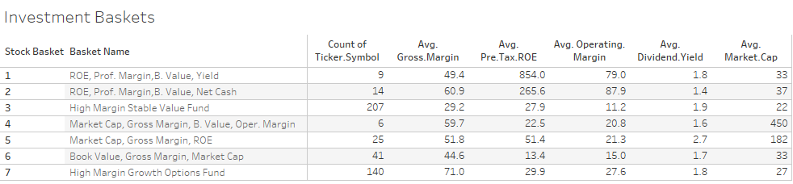

Investment Basket Table

[Visualize Result Table](https://public.tableau.com/profile/raju.penmetcha#!/vizhome/RUWeek8a/Sheet2)

*Heat Map*

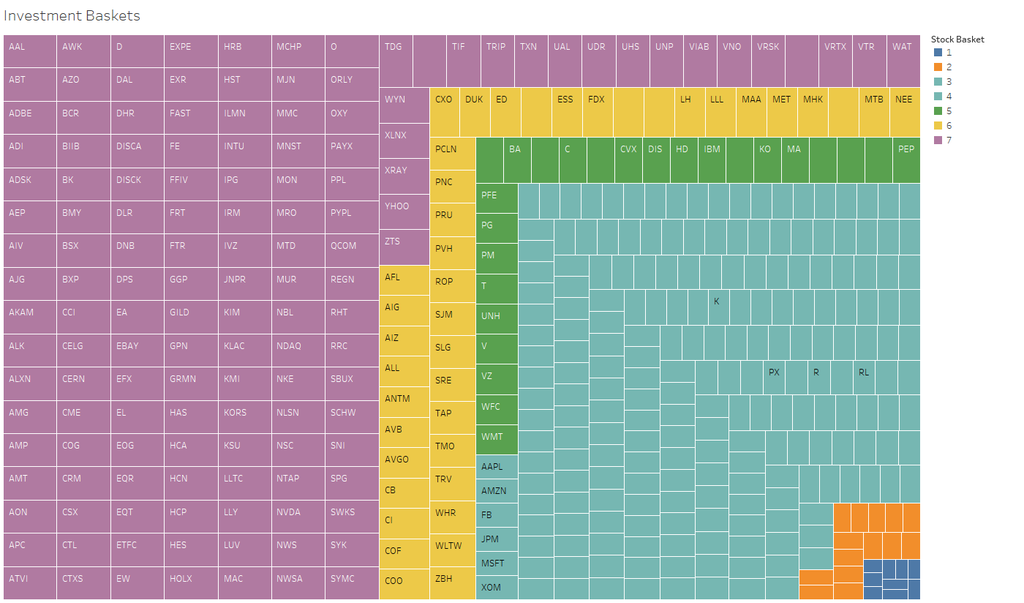

[Visualize Result Heatmap](https://public.tableau.com/profile/raju.penmetcha#!/vizhome/RUWeek8a/Sheet1)

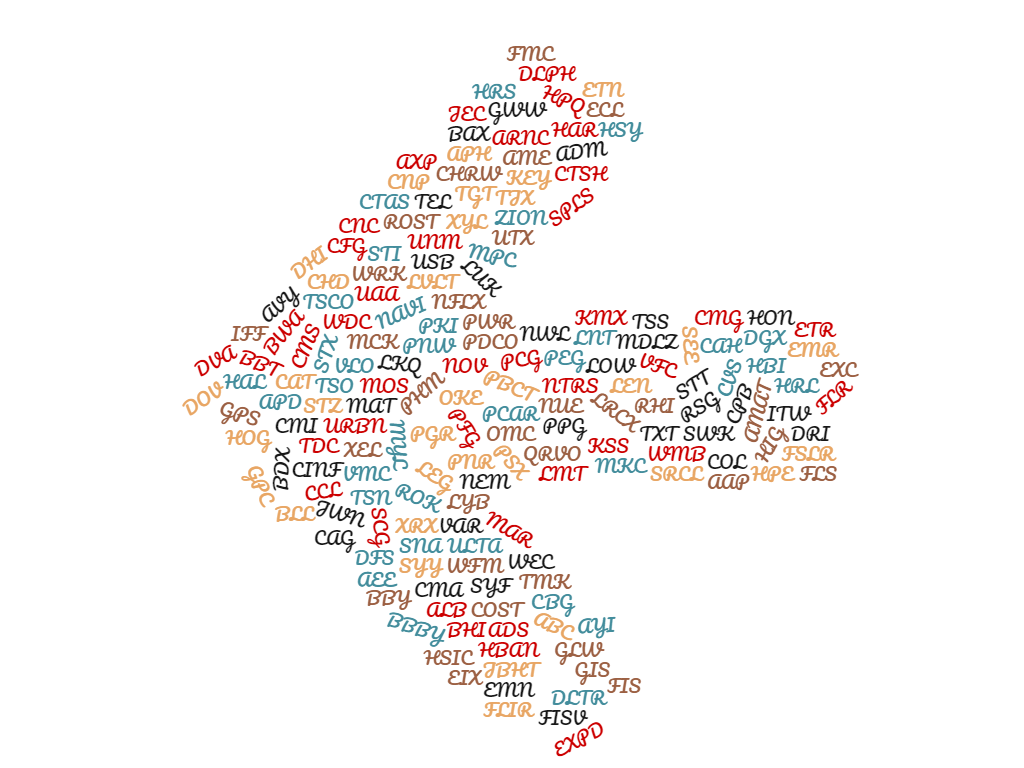

High Margin Stable Value Fund Stocks

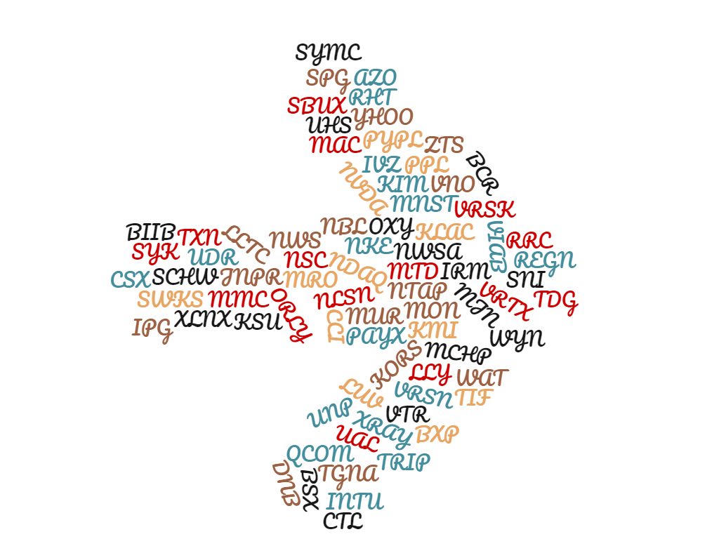

High Margin Growth Options Fund Stocks

### Using Pseudo t^2 to Get an Automatic Pick

```r
library(NbClust)
NbClust(data=interests, min.nc=2, max.nc=9, method="complete", index="pseudot2")
```

```
## $All.index
##        2        3        4        5        6        7        8        9
## 152.0777  -5.3651 170.7233   8.7405  -3.0149 210.2550  21.5470   6.7327
##
## $All.CriticalValues
##       2       3       4       5       6       7       8       9
## 46.3277  5.0953 45.8822  5.3740  4.1037 45.1368 43.1813  4.7961
##
## $Best.nc
## Number_clusters     Value_Index
##          3.0000         -5.3651
##
## $Best.partition
##   [1] 1 1 2 1 1 1 1 1 1 1 1 1 1 1 1 1 1 1 1 1 1 1 3 1 1 1 1 1 1 1 2 1 1 1 3
##  [36] 1 1 1 1 1 1 1 1 1 1 1 1 1 1 1 1 1 1 1 1 1 1 1 1 1 1 1 1 1 1 1 1 1 1 1
##  [71] 1 1 1 1 1 1 3 1 3 1 1 3 3 1 1 1 1 1 1 1 1 1 1 1 1 1 1 1 1 1 1 1 1 1 1
## [106] 1 1 1 1 1 1 1 1 1 1 1 1 1 1 1 1 1 1 1 1 1 1 1 1 1 1 1 1 1 1 1 1 1 1 1
## [141] 1 1 1 1 1 1 1 1 1 1 1 1 1 2 1 1 1 1 1 1 1 1 1 1 1 1 1 1 1 1 1 1 1 1 1
## [176] 1 1 1 1 1 1 1 1 1 1 1 1 1 1 1 1 1 1 1 1 1 1 1 1 1 1 1 1 1 1 1 1 1 1 1
## [211] 1 1 1 1 1 1 1 1 1 1 2 1 1 1 1 1 3 1 1 1 1 1 1 1 3 1 1 1 1 1 1 1 1 1 1
## [246] 1 1 1 1 1 1 1 1 1 1 1 1 1 1 1 1 1 1 1 1 1 1 1 1 1 1 1 1 1 1 1 2 1 1 1
## [281] 1 1 1 1 1 1 1 1 1 1 1 1 1 1 1 1 1 1 1 1 1 1 1 1 1 1 1 1 1 1 1 1 1 1 1
## [316] 1 1 1 1 1 1 1 1 1 1 1 1 1 1 1 1 1 1 1 1 1 1 1 1 1 1 1 1 1 1 1 1 1 1 1
## [351] 1 1 1 1 1 3 1 1 1 1 1 1 1 1 1 1 1 1 1 1 1 1 1 1 1 1 1 1 1 1 1 1 1 1 1
## [386] 1 1 1 1 1 1 1 1 1 1 1 1 1 1 1 1 1 1 1 1 1 1 1 1 1 1 1 1 1 1 1 1 1 1 1
## [421] 1 1 1 1 1 1 1 1 1 1 1 1 1 2 1 1 1 1 1 1 1 1
```

**Based on above automatic pick analysis it appears cluster run of 3 to be good fit, howerver the original goal to exclude high market cap companies from the selected basket or grouping did not achived therefor this cluster 3 pick may need even further analysis and also may need more data points to get better overall results.**